# RNA-Seq Workflow Template

## 4.2 Read mapping with `HISAT2`

```r
args <- systemArgs(sysma="param/hisat2.param", mytargets="targets.txt")
cat(system(paste0('cat param/hisat2.param'), intern = T), sep = '\n')
names(args)
modules(args)
cores(args)
outpaths(args)
sysargs(args) # shows hisat2 calls
sysargs(args)[1] # Command-line parameters for first FASTQ file
moduleload(modules(args))
system('pwd')
cat(system("hisat2-build ./data/tair10.fasta ./data/tair10.fasta > results/hisat2-build.out 2> results/hisat2-build.err", intern = T), sep = '\n')
system('pwd')
cat(system(paste0('cat results/hisat2-build.err'), intern = T), sep = '\n')
cat(system(paste0('cat results/hisat2-build.out'), intern = T), sep = '\n')
resources <- list(walltime="01:00:00", ntasks=1, ncpus=cores(args), memory="10G")
resources
reg <- clusterRun(args, conffile=".BatchJobs.R", template="slurm.tmpl", Njobs=18, runid="01",
                  resourceList=resources)
# don't submit for 20 hours on short-list!
# 1 minute
reg
waitForJobs(reg)
```

Check whether all BAM files have been created

```r
outpaths(args)
```

```
##                                                                                                             M1A
## "/bigdata/girkelab/gdmosher/code/systemPipeRstudy/rnaseq/results/SRR446027_1.fastq.gz.tophat/accepted_hits.bam"
##                                                                                                             M1B
## "/bigdata/girkelab/gdmosher/code/systemPipeRstudy/rnaseq/results/SRR446028_1.fastq.gz.tophat/accepted_hits.bam"
##                                                                                                             A1A
## "/bigdata/girkelab/gdmosher/code/systemPipeRstudy/rnaseq/results/SRR446029_1.fastq.gz.tophat/accepted_hits.bam"
##                                                                                                             A1B
## "/bigdata/girkelab/gdmosher/code/systemPipeRstudy/rnaseq/results/SRR446030_1.fastq.gz.tophat/accepted_hits.bam"
##                                                                                                             V1A
## "/bigdata/girkelab/gdmosher/code/systemPipeRstudy/rnaseq/results/SRR446031_1.fastq.gz.tophat/accepted_hits.bam"
##                                                                                                             V1B
## "/bigdata/girkelab/gdmosher/code/systemPipeRstudy/rnaseq/results/SRR446032_1.fastq.gz.tophat/accepted_hits.bam"
##                                                                                                             M6A
## "/bigdata/girkelab/gdmosher/code/systemPipeRstudy/rnaseq/results/SRR446033_1.fastq.gz.tophat/accepted_hits.bam"
##                                                                                                             M6B
## "/bigdata/girkelab/gdmosher/code/systemPipeRstudy/rnaseq/results/SRR446034_1.fastq.gz.tophat/accepted_hits.bam"
##                                                                                                             A6A
## "/bigdata/girkelab/gdmosher/code/systemPipeRstudy/rnaseq/results/SRR446035_1.fastq.gz.tophat/accepted_hits.bam"
##                                                                                                             A6B
## "/bigdata/girkelab/gdmosher/code/systemPipeRstudy/rnaseq/results/SRR446036_1.fastq.gz.tophat/accepted_hits.bam"
##                                                                                                             V6A
## "/bigdata/girkelab/gdmosher/code/systemPipeRstudy/rnaseq/results/SRR446037_1.fastq.gz.tophat/accepted_hits.bam"
##                                                                                                             V6B
## "/bigdata/girkelab/gdmosher/code/systemPipeRstudy/rnaseq/results/SRR446038_1.fastq.gz.tophat/accepted_hits.bam"
##                                                                                                            M12A
## "/bigdata/girkelab/gdmosher/code/systemPipeRstudy/rnaseq/results/SRR446039_1.fastq.gz.tophat/accepted_hits.bam"
##                                                                                                            M12B
## "/bigdata/girkelab/gdmosher/code/systemPipeRstudy/rnaseq/results/SRR446040_1.fastq.gz.tophat/accepted_hits.bam"
##                                                                                                            A12A
## "/bigdata/girkelab/gdmosher/code/systemPipeRstudy/rnaseq/results/SRR446041_1.fastq.gz.tophat/accepted_hits.bam"
##                                                                                                            A12B
## "/bigdata/girkelab/gdmosher/code/systemPipeRstudy/rnaseq/results/SRR446042_1.fastq.gz.tophat/accepted_hits.bam"
##                                                                                                            V12A
## "/bigdata/girkelab/gdmosher/code/systemPipeRstudy/rnaseq/results/SRR446043_1.fastq.gz.tophat/accepted_hits.bam"
##                                                                                                            V12B
## "/bigdata/girkelab/gdmosher/code/systemPipeRstudy/rnaseq/results/SRR446044_1.fastq.gz.tophat/accepted_hits.bam"
```

```r
file.exists(outpaths(args))
```

```
##  [1] TRUE TRUE TRUE TRUE TRUE TRUE TRUE TRUE TRUE TRUE TRUE TRUE TRUE TRUE TRUE TRUE TRUE TRUE
```

## 4.3 Read and alignment stats

The following provides an overview of the number of reads in each sample and how many of them aligned to the reference.

```r
read_statsDF <- systemPipeR::alignStats(args=args)
read_statsDF
write.table(read_statsDF, "results/alignStats.xls", row.names=FALSE, quote=FALSE, sep="\t")
```

The following shows the alignment statistics for a sample file provided by the `systemPipeR` package.

```r
read.table(system.file("extdata", "alignStats.xls", package="systemPipeR"), header=TRUE)[1:4,]
```

```
##   FileName Nreads2x Nalign Perc_Aligned Nalign_Primary Perc_Aligned_Primary
## 1      M1A   192918 177961     92.24697         177961             92.24697
## 2      M1B   197484 159378     80.70426         159378             80.70426
## 3      A1A   189870 176055     92.72397         176055             92.72397
## 4      A1B   188854 147768     78.24457         147768             78.24457
```

## 4.4 Create symbolic links for viewing BAM files in IGV

The `symLink2bam` function creates symbolic links to view the BAM alignment files in a genome browser such as IGV. The corresponding URLs are written to a file with a path specified under `urlfile` in the `results` directory.

```r
symLink2bam(sysargs=args, htmldir=c("~/.html/", "somedir/"),
            urlbase="http://biocluster.ucr.edu/~tgirke/",
            urlfile="./results/IGVurl.txt")
```

# 5 (5)Read quantification

## 5.1 Read counting with `summarizeOverlaps` in parallel mode using multiple cores

```r
# uses >3GB memory
library("GenomicFeatures"); library(BiocParallel)
cat(system(paste0('head data/tair10.gff'), intern = T), sep = '\n')
```

```
## ##gff-version 1
## ##date 2011-05-26
## Chr1 TAIR10  chromosome  1   100000  0   *   .   ID=Chr1;Name=Chr1
## Chr1 TAIR10  gene    3631    5899    0   +   .   ID=AT1G01010;Note=protein_coding_gene;Name=AT1G01010
## Chr1 TAIR10  mRNA    3631    5899    0   +   .   ID=AT1G01010.1;Parent=AT1G01010;Name=AT1G01010.1;Index=1
## Chr1 TAIR10  protein 3760    5630    0   +   .   ID=AT1G01010.1-Protein;Name=AT1G01010.1;Derives_from=AT1G01010.1
## Chr1 TAIR10  exon    3631    3913    0   +   .   Parent=AT1G01010.1
## Chr1 TAIR10  five_prime_UTR  3631    3759    0   +   .   Parent=AT1G01010.1
## Chr1 TAIR10  CDS 3760    3913    0   +   0   Parent=AT1G01010.1,AT1G01010.1-Protein;
## Chr1 TAIR10  exon    3996    4276    0   +   .   Parent=AT1G01010.1
```

```r
cat(system(paste0('tail data/tair10.gff'), intern = T), sep = '\n')
```

```
## ChrM TAIR10  CDS 51293   51871   0   -   0   Parent=ATMG00180.1,ATMG00180.1-Protein;
## ChrM TAIR10  exon    51293   51871   0   -   .   Parent=ATMG00180.1
## ChrM TAIR10  gene    53736   53809   0   -   .   ID=ATMG00190;Note=tRNA;Name=ATMG00190
## ChrM TAIR10  tRNA    53736   53809   0   -   .   ID=ATMG00190.1;Parent=ATMG00190;Name=ATMG00190.1;Index=1
## ChrM TAIR10  exon    53736   53809   0   -   .   Parent=ATMG00190.1
## ChrM TAIR10  gene    55767   56090   0   -   .   ID=ATMG00200;Note=protein_coding_gene;Name=ATMG00200
## ChrM TAIR10  mRNA    55767   56090   0   -   .   ID=ATMG00200.1;Parent=ATMG00200;Name=ATMG00200.1;Index=1
## ChrM TAIR10  protein 55767   56090   0   -   .   ID=ATMG00200.1-Protein;Name=ATMG00200.1;Derives_from=ATMG00200.1
## ChrM TAIR10  CDS 55767   56090   0   -   0   Parent=ATMG00200.1,ATMG00200.1-Protein;
## ChrM TAIR10  exon    55767   56090   0   -   .   Parent=ATMG00200.1
```

```r
txdb <- GenomicFeatures::makeTxDbFromGFF(file="data/tair10.gff", format="gff", dataSource="TAIR", organism="Arabidopsis thaliana")
```

```
## Import genomic features from the file as a GRanges object ...
```

```
## OK
```

```
## Prepare the 'metadata' data frame ... OK
## Make the TxDb object ...
```

```
## OK
```

```r
txdb
```

```
## TxDb object:
## # Db type: TxDb
## # Supporting package: GenomicFeatures
## # Data source: TAIR
## # Organism: Arabidopsis thaliana
## # Taxonomy ID: 3702
## # miRBase build ID: NA
## # Genome: NA
## # transcript_nrow: 172
## # exon_nrow: 498
## # cds_nrow: 425
## # Db created by: GenomicFeatures package from Bioconductor
## # Creation time: 2018-06-19 13:45:37 -0700 (Tue, 19 Jun 2018)
## # GenomicFeatures version at creation time: 1.32.0
## # RSQLite version at creation time: 2.1.1
## # DBSCHEMAVERSION: 1.2
```

```r
saveDb(txdb, file="./data/tair10.sqlite")
```

```
## TxDb object:
## # Db type: TxDb
## # Supporting package: GenomicFeatures
## # Data source: TAIR
## # Organism: Arabidopsis thaliana
## # Taxonomy ID: 3702
## # miRBase build ID: NA
## # Genome: NA
## # transcript_nrow: 172
## # exon_nrow: 498
## # cds_nrow: 425
## # Db created by: GenomicFeatures package from Bioconductor
## # Creation time: 2018-06-19 13:45:37 -0700 (Tue, 19 Jun 2018)
## # GenomicFeatures version at creation time: 1.32.0
## # RSQLite version at creation time: 2.1.1
## # DBSCHEMAVERSION: 1.2
```

```r
txdb <- loadDb("./data/tair10.sqlite")
outpaths(args)[1]
```

```
##                                                                                                             M1A
## "/bigdata/girkelab/gdmosher/code/systemPipeRstudy/rnaseq/results/SRR446027_1.fastq.gz.tophat/accepted_hits.bam"
```

```r
(align <- GenomicAlignments::readGAlignments(outpaths(args)[1])) # Demonstrates how to read bam file into R
```

```
## GAlignments object with 89376 alignments and 0 metadata columns:
##           seqnames strand         cigar    qwidth     start       end     width     njunc
##              <Rle>  <Rle>   <character> <integer> <integer> <integer> <integer> <integer>
##       [1]     Chr1      +           75M        75      3736      3810        75         0
##       [2]     Chr1      +           75M        75      3749      3823        75         0
##       [3]     Chr1      +           75M        75      3749      3823        75         0
##       [4]     Chr1      -     44M82N31M        75      3870      4026       157         1
##       [5]     Chr1      +           75M        75      4055      4129        75         0
##       ...      ...    ...           ...       ...       ...       ...       ...       ...
##   [89372]     ChrM      -           75M        75     89171     89245        75         0
##   [89373]     ChrM      -           75M        75     91919     91993        75         0
##   [89374]     ChrM      -           75M        75     94165     94239        75         0
##   [89375]     ChrM      + 21M1D21M1D33M        75     95482     95558        77         0
##   [89376]     ChrM      -           75M        75     99510     99584        75         0
##   -------
##   seqinfo: 7 sequences from an unspecified genome
```

```r
align
```

```
## GAlignments object with 89376 alignments and 0 metadata columns:
##           seqnames strand         cigar    qwidth     start       end     width     njunc
##              <Rle>  <Rle>   <character> <integer> <integer> <integer> <integer> <integer>
##       [1]     Chr1      +           75M        75      3736      3810        75         0
##       [2]     Chr1      +           75M        75      3749      3823        75         0
##       [3]     Chr1      +           75M        75      3749      3823        75         0
##       [4]     Chr1      -     44M82N31M        75      3870      4026       157         1
##       [5]     Chr1      +           75M        75      4055      4129        75         0
##       ...      ...    ...           ...       ...       ...       ...       ...       ...
##   [89372]     ChrM      -           75M        75     89171     89245        75         0
##   [89373]     ChrM      -           75M        75     91919     91993        75         0
##   [89374]     ChrM      -           75M        75     94165     94239        75         0
##   [89375]     ChrM      + 21M1D21M1D33M        75     95482     95558        77         0
##   [89376]     ChrM      -           75M        75     99510     99584        75         0
##   -------
##   seqinfo: 7 sequences from an unspecified genome
```

```r
eByg <- GenomicFeatures::exonsBy(txdb, by=c("gene"))
eByg
```

```
## GRangesList object of length 145:
## $AT1G01010
## GRanges object with 6 ranges and 2 metadata columns:
##       seqnames    ranges strand |   exon_id   exon_name
##          <Rle> <IRanges>  <Rle> | <integer> <character>
##   [1]     Chr1 3631-3913      + |         1        <NA>
##   [2]     Chr1 3996-4276      + |         2        <NA>
##   [3]     Chr1 4486-4605      + |         3        <NA>
##   [4]     Chr1 4706-5095      + |         4        <NA>
##   [5]     Chr1 5174-5326      + |         5        <NA>
##   [6]     Chr1 5439-5899      + |         6        <NA>
##
## $AT1G01020
## GRanges object with 12 ranges and 2 metadata columns:
##        seqnames    ranges strand | exon_id exon_name
##    [1]     Chr1 5928-6263      - |      40      <NA>
##    [2]     Chr1 6437-7069      - |      41      <NA>
##    [3]     Chr1 6790-7069      - |      42      <NA>
##    [4]     Chr1 7157-7232      - |      43      <NA>
##    [5]     Chr1 7157-7450      - |      44      <NA>
##    ...      ...       ...    ... .     ...       ...
##    [8]     Chr1 7762-7835      - |      47      <NA>
##    [9]     Chr1 7942-7987      - |      48      <NA>
##   [10]     Chr1 8236-8325      - |      49      <NA>
##   [11]     Chr1 8417-8464      - |      50      <NA>
##   [12]     Chr1 8571-8737      - |      51      <NA>
##
## $AT1G01030
## GRanges object with 2 ranges and 2 metadata columns:
##       seqnames      ranges strand | exon_id exon_name
##   [1]     Chr1 11649-13173      - |      52      <NA>
##   [2]     Chr1 13335-13714      - |      53      <NA>
##
## ...
## <142 more elements>
## -------
## seqinfo: 7 sequences (2 circular) from an unspecified genome; no seqlengths
```

```r
bfl <- Rsamtools::BamFileList(outpaths(args), yieldSize=50000, index=character())
bfl
```

```
## BamFileList of length 18
## names(18): M1A M1B A1A A1B V1A V1B M6A M6B A6A A6B V6A V6B M12A M12B A12A A12B V12A V12B
```

```r
multicoreParam <- MulticoreParam(workers=2); register(multicoreParam); registered()
```

```
## $MulticoreParam
## class: MulticoreParam
##   bpisup: FALSE; bpnworkers: 2; bptasks: 0; bpjobname: BPJOB
##   bplog: FALSE; bpthreshold: INFO; bpstopOnError: TRUE
##   bptimeout: 2592000; bpprogressbar: FALSE
##   bpRNGseed:
##   bplogdir: NA
##   bpresultdir: NA
##   cluster type: FORK
##
## $SnowParam
## class: SnowParam
##   bpisup: FALSE; bpnworkers: 62; bptasks: 0; bpjobname: BPJOB
##   bplog: FALSE; bpthreshold: INFO; bpstopOnError: TRUE
##   bptimeout: 2592000; bpprogressbar: FALSE
##   bpRNGseed:
##   bplogdir: NA
##   bpresultdir: NA
##   cluster type: SOCK
##
## $SerialParam
## class: SerialParam
##   bpisup: TRUE; bpnworkers: 1; bptasks: 0; bpjobname: BPJOB
##   bplog: FALSE; bpthreshold: INFO; bpstopOnError: TRUE
##   bptimeout: 2592000; bpprogressbar: FALSE
##   bplogdir: NA
```

```r
multicoreParam
```

```
## class: MulticoreParam
##   bpisup: FALSE; bpnworkers: 2; bptasks: 0; bpjobname: BPJOB
##   bplog: FALSE; bpthreshold: INFO; bpstopOnError: TRUE
##   bptimeout: 2592000; bpprogressbar: FALSE
##   bpRNGseed:
##   bplogdir: NA
##   bpresultdir: NA
##   cluster type: FORK
```

```r
counteByg <- bplapply(bfl, function(x) GenomicAlignments::summarizeOverlaps(eByg, x, mode="Union",
                                               ignore.strand=TRUE,
                                               inter.feature=FALSE,
                                               singleEnd=TRUE))
str(counteByg)
```

[output not shown]

[output cut: 1494 more lines]

[output not shown]

```r
counteByg
```

```
## $M1A
## class: RangedSummarizedExperiment
## dim: 145 1
## metadata(0):
## assays(1): counts
## rownames(145): AT1G01010 AT1G01020 ... ATMG00190 ATMG00200
## rowData names(0):
## colnames(1): accepted_hits.bam
## colData names(0):
##
## $M1B
## class: RangedSummarizedExperiment
## dim: 145 1
## metadata(0):
## assays(1): counts
## rownames(145): AT1G01010 AT1G01020 ... ATMG00190 ATMG00200
## rowData names(0):
## colnames(1): accepted_hits.bam
## colData names(0):
##
## $A1A
## class: RangedSummarizedExperiment
## dim: 145 1
## metadata(0):
## assays(1): counts
## rownames(145): AT1G01010 AT1G01020 ... ATMG00190 ATMG00200
## rowData names(0):
## colnames(1): accepted_hits.bam
## colData names(0):
##
## $A1B
## class: RangedSummarizedExperiment
## dim: 145 1
## metadata(0):
## assays(1): counts
## rownames(145): AT1G01010 AT1G01020 ... ATMG00190 ATMG00200
## rowData names(0):
## colnames(1): accepted_hits.bam
## colData names(0):
##
```

[output cut: 124 more lines]

```
## assays(1): counts
## rownames(145): AT1G01010 AT1G01020 ... ATMG00190 ATMG00200
## rowData names(0):
## colnames(1): accepted_hits.bam
## colData names(0):
##
## $V12B
## class: RangedSummarizedExperiment
## dim: 145 1
## metadata(0):
## assays(1): counts
## rownames(145): AT1G01010 AT1G01020 ... ATMG00190 ATMG00200
## rowData names(0):
## colnames(1): accepted_hits.bam
## colData names(0):
```

```r
countDFeByg <- sapply(seq(along=counteByg), function(x) SummarizedExperiment::assays(counteByg[[x]])$counts)
str(countDFeByg)
```

```
##  int [1:145, 1:18] 28 12 19 98 2 33 12 0 0 49 ...
```

```r
countDFeByg
```

```
##         [,1]  [,2]  [,3]  [,4]  [,5]  [,6]  [,7]  [,8]  [,9] [,10] [,11] [,12] [,13] [,14] [,15]
##   [1,]    28   128    99    87   183   118    22    19    77    23   148   201    60    68    66
##   [2,]    12    47    35    50    49    41     9    11     9     3    42    71    21    37    16
##   [3,]    19    51    36    33    47    78     5     8     4     4    18    73    16    15     7
##   [4,]    98   354   259   345   298   350    82    81   128    34   359   530   171   298   183
##   [5,]     2     2     6     2     6     5     1     1     3     0     4     8     3     4     4
##   [6,]    33    66    49    78    71   157    59    87    68    18   123   341   180   365    97
##   [7,]    12   137    29    26     4    12     3     1     0     0     0     2    43    96    54
##   [8,]     0     0     1     1     2     3     1     2     3     2     2     5     3    20     4
##   [9,]     0     0     0     0     0     0     0     0     0     0     0     0     0     0     0
##  [10,]    49   199    88   235   143   276    49   109    40    21    72   281   126   310    38
##  [11,]   165   549   385   717   325   927   176   262   163    72   307   852   406   827   139
##  [12,]   111   246   262   254   246   447   247   307   477    94   684  1214   396   882   363
##  [13,]     2     6     6     3     2     9     2     1     2     1     0     8     4    18     2
##  [14,]     0     0     0     0     0     0     0     0     0     0     0     0     0     0     0
```

[output cut: 98 more lines]

```r
rownames(countDFeByg) <- names(rowRanges(counteByg[[1]])); colnames(countDFeByg) <- names(bfl)
rownames(countDFeByg)
```

```
##   [1] "AT1G01010" "AT1G01020" "AT1G01030" "AT1G01040" "AT1G01046" "AT1G01050" "AT1G01060"
##   [8] "AT1G01070" "AT1G01073" "AT1G01080" "AT1G01090" "AT1G01100" "AT1G01110" "AT1G01115"
##  [15] "AT2G01008" "AT2G01010" "AT2G01020" "AT2G01021" "AT2G01023" "AT3G01010" "AT3G01015"
##  [22] "AT3G01020" "AT3G01030" "AT3G01040" "AT3G01050" "AT3G01060" "AT3G01070" "AT3G01080"
##  [29] "AT3G01085" "AT3G01090" "AT3G01100" "AT3G01120" "AT3G01130" "AT3G01140" "AT3G01142"
##  [36] "AT3G01150" "AT3G01160" "AT3G01170" "AT4G00005" "AT4G00020" "AT4G00026" "AT4G00030"
##  [43] "AT4G00040" "AT4G00050" "AT4G00060" "AT4G00070" "AT4G00080" "AT4G00085" "AT4G00090"
##  [50] "AT4G00100" "AT4G00110" "AT4G00114" "AT4G00120" "AT4G00124" "AT4G00130" "AT4G00140"
##  [57] "AT5G01010" "AT5G01015" "AT5G01020" "AT5G01030" "AT5G01040" "AT5G01050" "AT5G01060"
##  [64] "AT5G01070" "AT5G01075" "AT5G01080" "AT5G01090" "AT5G01100" "AT5G01110" "AT5G01120"
##  [71] "AT5G01130" "AT5G01140" "AT5G01150" "AT5G01160" "ATCG00010" "ATCG00020" "ATCG00030"
##  [78] "ATCG00040" "ATCG00050" "ATCG00060" "ATCG00070" "ATCG00080" "ATCG00090" "ATCG00100"
##  [85] "ATCG00110" "ATCG00120" "ATCG00130" "ATCG00140" "ATCG00150" "ATCG00160" "ATCG00170"
##  [92] "ATCG00180" "ATCG00190" "ATCG00200" "ATCG00210" "ATCG00220" "ATCG00230" "ATCG00240"
##  [99] "ATCG00250" "ATCG00260" "ATCG00270" "ATCG00280" "ATCG00290" "ATCG00300" "ATCG00310"
## [106] "ATCG00320" "ATCG00330" "ATCG00340" "ATCG00350" "ATCG00360" "ATCG00370" "ATCG00380"
## [113] "ATCG00390" "ATCG00400" "ATCG00410" "ATCG00420" "ATCG00430" "ATCG00440" "ATCG00450"
## [120] "ATCG00460" "ATCG00470" "ATCG00480" "ATCG00490" "ATCG00500" "ATCG00510" "ATMG00010"
## [127] "ATMG00020" "ATMG00030" "ATMG00040" "ATMG00050" "ATMG00060" "ATMG00070" "ATMG00080"
## [134] "ATMG00090" "ATMG00100" "ATMG00110" "ATMG00120" "ATMG00130" "ATMG00140" "ATMG00150"
## [141] "ATMG00160" "ATMG00170" "ATMG00180" "ATMG00190" "ATMG00200"
```

```r
rpkmDFeByg <- apply(countDFeByg, 2, function(x) returnRPKM(counts=x, ranges=eByg))
str(rpkmDFeByg)
```

```
##  num [1:145, 1:18] 394 161 237 372 230 ...
##  - attr(*, "dimnames")=List of 2
##   ..$ : chr [1:145] "AT1G01010" "AT1G01020" "AT1G01030" "AT1G01040" ...
##   ..$ : chr [1:18] "M1A" "M1B" "A1A" "A1B" ...
```

```r
rpkmDFeByg
```

```
##                    M1A          M1B          A1A          A1B          V1A          V1B
## AT1G01010 3.940815e+02   1680.16892   1197.04641   1033.96963   2633.47638   1256.72294
## AT1G01020 1.607045e+02    587.02914    402.68242    565.42807    670.95477    415.48966
## AT1G01030 2.369513e+02    593.18562    385.70544    347.52010    599.31295    736.08776
## AT1G01040 3.722791e+02   1254.18270    845.25963   1106.68033   1157.46847   1006.09767
## AT1G01046 2.295409e+02    214.07949    591.60133    193.82983    704.09569    434.23981
## AT1G01050 8.032756e+02   1498.33712   1024.69472   1603.26665   1767.09261   2891.87696
## AT1G01060 8.815393e+01    938.63333    183.02323    161.28512     30.04490     66.70697
## AT1G01070 0.000000e+00      0.00000     14.07603     13.83544     33.50524     37.19489
## AT1G01073 0.000000e+00      0.00000      0.00000      0.00000      0.00000      0.00000
## AT1G01080 8.805724e+02   3335.31642   1358.62454   3566.13173   2627.57646   3753.25095
## AT1G01090 2.409333e+03   7476.53227   4829.71401   8840.82058   4852.28821  10242.88171
## AT1G01100 3.883771e+03   8027.50812   7875.52936   7504.55451   8800.67764  11834.98536
## AT1G01110 2.566989e+01     71.82246     66.15963     32.51440     26.24668     87.41100
## AT1G01115 0.000000e+00      0.00000      0.00000      0.00000      0.00000      0.00000
## AT2G01008 2.684461e+02    679.55985    411.82901    275.25714    509.74482    449.80094
## AT2G01010 4.550452e+05 397763.90435 424754.37714 412778.58921 421510.50620 420413.64224
## AT2G01020 4.592148e+04   8916.93309  28997.48357   5993.95125  19403.41749  26308.57769
## AT2G01021 6.766224e+05 345826.53411 737970.46117 226575.67451 361511.71912  94117.64706
## AT2G01023 0.000000e+00   1661.79208    340.17077    668.71293      0.00000    149.81273
## AT3G01010 0.000000e+00      0.00000      0.00000      0.00000      0.00000      0.00000
## AT3G01015 0.000000e+00      0.00000      0.00000     11.43751      0.00000      0.00000
## AT3G01020 0.000000e+00      0.00000      0.00000      0.00000      0.00000      0.00000
## AT3G01030 0.000000e+00      0.00000      0.00000      0.00000      0.00000      0.00000
## AT3G01040 4.747699e+02   2081.11451   1492.83573   2413.46033   1854.37192   2636.99153
## AT3G01050 5.334150e+02   2257.81767   1938.79711   2875.81207   2349.41774   2390.79389
## AT3G01060 1.795795e+03   6205.12200   3705.20574   4673.53273   1956.54843   2071.75974
## AT3G01070 0.000000e+00    130.95288     72.37676     23.71322     57.42624     63.75010
## AT3G01080 2.801590e+02    243.86886   1251.57169    110.40072    515.61724    664.26401
## AT3G01085 0.000000e+00      0.00000      0.00000      0.00000      0.00000      0.00000
## AT3G01090 3.587196e+02   1290.43388   1400.01256   1696.30372   1750.06355   1372.74481
## AT3G01100 1.496796e+02    589.41173    292.90167    428.33205    416.61665    629.24495
## AT3G01120 3.775249e+03  11921.65966   9346.32122  10398.87517   9209.81745   9511.83447
## AT3G01130 9.085723e+02   2071.35556   2139.31756   2045.92057   4197.64696   3284.84578
## AT3G01140 0.000000e+00     86.15902     26.45528    312.03714     15.74290      0.00000
## AT3G01142 0.000000e+00     84.19466     25.85212    304.92293     15.38398      0.00000
## AT3G01150 2.515683e+02    821.18117   1269.73072   1022.32089   1141.41786   2248.67823
## AT3G01160 1.779979e+02   1122.99744    530.72037   1458.84927    674.46099    483.30948
## AT3G01170 3.369856e+02   1257.14767   1334.94910   1991.91085   1129.38280   2153.33670
## AT4G00005 0.000000e+00      0.00000      0.00000      0.00000      0.00000      0.00000
```

[output cut: 114 more lines]

```
## AT4G00030 3.491000e+03   5404.48411 2.349259e+03 4.837112e+02 1.785269e+03 1.212884e+03
## AT4G00040 2.813029e+03   4568.05305 1.623412e+03 4.661346e+02 1.158635e+03 7.346817e+02
## AT4G00050 3.381074e+03   3499.16992 1.735117e+03 1.069073e+02 1.612103e+03 6.318682e+02
## AT4G00060 6.052139e+02    815.56057 3.684722e+02 1.457216e+02 3.464608e+02 1.872342e+02
## AT4G00070 0.000000e+00      0.00000 0.000000e+00 0.000000e+00 0.000000e+00 0.000000e+00
## AT4G00080 0.000000e+00      0.00000 0.000000e+00 0.000000e+00 0.000000e+00 0.000000e+00
## AT4G00085 0.000000e+00      0.00000 0.000000e+00 0.000000e+00 0.000000e+00 0.000000e+00
## AT4G00090 4.176555e+02    932.82605 5.751313e+02 2.033722e+02 6.586907e+02 4.370972e+02
## AT4G00100 9.979971e+03  18009.15202 8.841070e+03 2.345427e+03 1.004029e+04 7.786950e+03
## AT4G00110 3.290709e+02    708.45070 2.553964e+02 1.132989e+02 1.564547e+02 1.860126e+02
## AT4G00114 0.000000e+00      0.00000 0.000000e+00 0.000000e+00 0.000000e+00 0.000000e+00
## AT4G00120 0.000000e+00      0.00000 0.000000e+00 0.000000e+00 0.000000e+00 0.000000e+00
## AT4G00124 0.000000e+00      0.00000 0.000000e+00 0.000000e+00 0.000000e+00 0.000000e+00
## AT4G00130 5.606725e+01    112.38160 1.174893e+02 4.343383e+01 0.000000e+00 4.278544e+01
##  [ reached getOption("max.print") -- omitted 90 rows ]
```

```r
write.table(countDFeByg, "results/countDFeByg.xls", col.names=NA, quote=FALSE, sep="\t")
write.table(rpkmDFeByg, "results/rpkmDFeByg.xls", col.names=NA, quote=FALSE, sep="\t")
```

Sample of data slice of RPKM table

Note, for most statistical differential expression or abundance analysis methods, such as `edgeR` or `DESeq2`, the raw count values should be used as input. The usage of RPKM values should be restricted to specialty applications required by some users, *e.g.* manually comparing the expression levels among different genes or features.

## 5.2 Sample-wise correlation analysis

The following computes the sample-wise Spearman correlation coefficients from the `rlog` transformed expression values generated with the `DESeq2` package. After transformation to a distance matrix, hierarchical clustering is performed with the `hclust` function and the result is plotted as a dendrogram (also see file `sample_tree.pdf`).

```r
library(DESeq2, quietly=TRUE); library(ape,  warn.conflicts=FALSE)
countDF <- as.matrix(read.table("./results/countDFeByg.xls"))
str(countDF)
```

```
##  int [1:145, 1:18] 28 12 19 98 2 33 12 0 0 49 ...
##  - attr(*, "dimnames")=List of 2
##   ..$ : chr [1:145] "AT1G01010" "AT1G01020" "AT1G01030" "AT1G01040" ...
##   ..$ : chr [1:18] "M1A" "M1B" "A1A" "A1B" ...
```

```r
countDF # exactly the same as countDFeByg above
```

```
##             M1A   M1B   A1A   A1B   V1A   V1B   M6A   M6B   A6A   A6B   V6A   V6B  M12A  M12B  A12A
## AT1G01010    28   128    99    87   183   118    22    19    77    23   148   201    60    68    66
## AT1G01020    12    47    35    50    49    41     9    11     9     3    42    71    21    37    16
## AT1G01030    19    51    36    33    47    78     5     8     4     4    18    73    16    15     7
## AT1G01040    98   354   259   345   298   350    82    81   128    34   359   530   171   298   183
## AT1G01046     2     2     6     2     6     5     1     1     3     0     4     8     3     4     4
## AT1G01050    33    66    49    78    71   157    59    87    68    18   123   341   180   365    97
## AT1G01060    12   137    29    26     4    12     3     1     0     0     0     2    43    96    54
## AT1G01070     0     0     1     1     2     3     1     2     3     2     2     5     3    20     4
## AT1G01073     0     0     0     0     0     0     0     0     0     0     0     0     0     0     0
## AT1G01080    49   199    88   235   143   276    49   109    40    21    72   281   126   310    38
## AT1G01090   165   549   385   717   325   927   176   262   163    72   307   852   406   827   139
## AT1G01100   111   246   262   254   246   447   247   307   477    94   684  1214   396   882   363
## AT1G01110     2     6     6     3     2     9     2     1     2     1     0     8     4    18     2
## AT1G01115     0     0     0     0     0     0     0     0     0     0     0     0     0     0     0
## AT2G01008    14    38    25    17    26    31    22    16    44    11    43    54    70   122    36
## AT2G01010 34630 32457 37626 37201 31373 42281 31159 24189 32577 27857 28916 40454 36803 36283 35580
## AT2G01020   317    66   233    49   131   240  3422   376  2222   542  2087   715  1318   911   542
## AT2G01021  2905  1592  3688  1152  1518   534  6265  5972  4812  5020  4649  1552  3534  1799  5461
## AT2G01023     0     9     2     4     0     1     0     0     0     1     3     4     3     1     0
## AT3G01010     0     0     0     0     0     0     0     0     0     0     0     0     0     0     0
## AT3G01015     0     0     0     1     0     0     0     0     0     0     1     0     0     0     0
## AT3G01020     0     0     0     0     0     0     0     0     0     0     0     0     0     0     0
## AT3G01030     0     0     0     0     0     0     0     0     0     0     0     0     0     0     0
## AT3G01040    50   235   183   301   191   367    24    37    41    12    74   132    73    65    42
## AT3G01050    13    59    55    83    56    77    22    29    24    11    54   143    23   102    46
## AT3G01060   122   452   293   376   130   186     4    31     6     1     8    20    50    90    21
## AT3G01070     0     5     3     1     2     3     0     0     0     0     0     1     0     2     1
## AT3G01080    15    14    78     7    27    47     8    12    34     4    30    15    15    20    43
## AT3G01085     0     0     0     0     0     0     0     0     0     0     0     0     0     0     0
## AT3G01090    35   135   159   196   167   177    43    63    75    24   119   236   128   187    82
## AT3G01100    18    76    41    61    49   100    14    24    34     7    66   134    64    91    59
## AT3G01120   355  1202  1023  1158   847  1182   398   603   597   138   878  1397  1026   908   382
## AT3G01130    27    66    74    72   122   129    42    59    80    14   172   188    54   158    92
## AT3G01140     0     6     2    24     1     0     7     7    11     4     8    26    26    40    10
## AT3G01142     0     6     2    24     1     0     7     8    11     4     8    26    26    41    10
## AT3G01150    16    56    94    77    71   189    21    45    30     8    62   144    66    94    39
## AT3G01160    17   115    59   165    63    61    24    38    46     9    90   140    32    61    30
## AT3G01170    18    72    83   126    59   152    26    29    35    12    69    59    49    47    38
## AT4G00005     0     0     0     0     0     0     0     0     0     0     0     0     0     0     0
```

[output cut: 58 more lines]

```
## AT4G00030    11    49    28
## AT4G00040    20    60    32
## AT4G00050     5    91    30
## AT4G00060    23    66    30
## AT4G00070     0     0     0
## AT4G00080     0     0     0
## AT4G00085     0     0     0
## AT4G00090    11    43    24
## AT4G00100    54   279   182
## AT4G00110     6    10    10
## AT4G00114     0     0     0
## AT4G00120     0     0     0
## AT4G00124     0     0     0
## AT4G00130     1     0     1
##  [ reached getOption("max.print") -- omitted 90 rows ]
```

```r
countDF[1:6,1:18]
```

```
##           M1A M1B A1A A1B V1A V1B M6A M6B A6A A6B V6A V6B M12A M12B A12A A12B V12A V12B
## AT1G01010  28 128  99  87 183 118  22  19  77  23 148 201   60   68   66   33  113   60
## AT1G01020  12  47  35  50  49  41   9  11   9   3  42  71   21   37   16    9   20   15
## AT1G01030  19  51  36  33  47  78   5   8   4   4  18  73   16   15    7    5   34   46
## AT1G01040  98 354 259 345 298 350  82  81 128  34 359 530  171  298  183   41  101   88
## AT1G01046   2   2   6   2   6   5   1   1   3   0   4   8    3    4    4    0    0    5
## AT1G01050  33  66  49  78  71 157  59  87  68  18 123 341  180  365   97   24  109   89
```

```r
head(countDF)
```

```
##           M1A M1B A1A A1B V1A V1B M6A M6B A6A A6B V6A V6B M12A M12B A12A A12B V12A V12B
## AT1G01010  28 128  99  87 183 118  22  19  77  23 148 201   60   68   66   33  113   60
## AT1G01020  12  47  35  50  49  41   9  11   9   3  42  71   21   37   16    9   20   15
## AT1G01030  19  51  36  33  47  78   5   8   4   4  18  73   16   15    7    5   34   46
## AT1G01040  98 354 259 345 298 350  82  81 128  34 359 530  171  298  183   41  101   88
## AT1G01046   2   2   6   2   6   5   1   1   3   0   4   8    3    4    4    0    0    5
## AT1G01050  33  66  49  78  71 157  59  87  68  18 123 341  180  365   97   24  109   89
```

```r
showClass("SYSargs")
```

```
## Class "SYSargs" [package "systemPipeR"]
##
## Slots:
##
## Name:      targetsin    targetsout targetsheader       modules      software         cores
## Class:    data.frame    data.frame     character     character     character       numeric
##
## Name:          other     reference       results       infile1       infile2      outfile1
## Class:     character     character     character     character     character     character
##
## Name:        sysargs      outpaths
## Class:     character     character
```

```r
systemPipeR::targetsin(args)$SampleName
```

```
##  [1] M1A  M1B  A1A  A1B  V1A  V1B  M6A  M6B  A6A  A6B  V6A  V6B  M12A M12B A12A A12B V12A V12B
## Levels: A12A A12B A1A A1B A6A A6B M12A M12B M1A M1B M6A M6B V12A V12B V1A V1B V6A V6B
```

```r
targetsin(args)$Factor
```

```
##  [1] M1  M1  A1  A1  V1  V1  M6  M6  A6  A6  V6  V6  M12 M12 A12 A12 V12 V12
## Levels: A1 A12 A6 M1 M12 M6 V1 V12 V6
```

```r
colData <- data.frame(row.names=targetsin(args)$SampleName, condition=targetsin(args)$Factor)
colData
```

```
##      condition
## M1A         M1
## M1B         M1
## A1A         A1
## A1B         A1
## V1A         V1
## V1B         V1
## M6A         M6
## M6B         M6
## A6A         A6
## A6B         A6
## V6A         V6
## V6B         V6
## M12A       M12
## M12B       M12
## A12A       A12
## A12B       A12
## V12A       V12
## V12B       V12
```

```r
dds <- DESeq2::DESeqDataSetFromMatrix(countData = countDF, colData = colData, design = ~ condition)
dds
```

```
## class: DESeqDataSet
## dim: 145 18
## metadata(1): version
## assays(1): counts
## rownames(145): AT1G01010 AT1G01020 ... ATMG00190 ATMG00200
## rowData names(0):
## colnames(18): M1A M1B ... V12A V12B
## colData names(1): condition
```

```r
d <- stats::cor(SummarizedExperiment::assay(DESeq2::rlog(dds)), method="spearman")
d
```

```
##            M1A       M1B       A1A       A1B       V1A       V1B       M6A       M6B       A6A
## M1A  1.0000000 0.9758120 0.9869812 0.9696950 0.9859676 0.9786082 0.9785175 0.9748852 0.9690245
## M1B  0.9758120 1.0000000 0.9776775 0.9916389 0.9810061 0.9838221 0.9688155 0.9735640 0.9652739
## A1A  0.9869812 0.9776775 1.0000000 0.9764509 0.9885548 0.9853799 0.9766836 0.9787581 0.9758869
## A1B  0.9696950 0.9916389 0.9764509 1.0000000 0.9801266 0.9851512 0.9656209 0.9741122 0.9657353
## V1A  0.9859676 0.9810061 0.9885548 0.9801266 1.0000000 0.9923961 0.9777011 0.9815977 0.9758475
## V1B  0.9786082 0.9838221 0.9853799 0.9851512 0.9923961 1.0000000 0.9709649 0.9810692 0.9740491
## M6A  0.9785175 0.9688155 0.9766836 0.9656209 0.9777011 0.9709649 1.0000000 0.9888979 0.9891345
## M6B  0.9748852 0.9735640 0.9787581 0.9741122 0.9815977 0.9810692 0.9888979 1.0000000 0.9887086
## A6A  0.9690245 0.9652739 0.9758869 0.9657353 0.9758475 0.9740491 0.9891345 0.9887086 1.0000000
## A6B  0.9762222 0.9717695 0.9803041 0.9742620 0.9766402 0.9742226 0.9806315 0.9833528 0.9796534
## V6A  0.9720140 0.9706928 0.9794128 0.9697778 0.9810219 0.9769045 0.9884601 0.9882274 0.9917296
## V6B  0.9594882 0.9638856 0.9711306 0.9650925 0.9715250 0.9724873 0.9835105 0.9882905 0.9861805
## M12A 0.9662599 0.9740451 0.9753427 0.9721047 0.9729369 0.9727673 0.9863186 0.9878015 0.9873558
## M12B 0.9591293 0.9633177 0.9681845 0.9594921 0.9651358 0.9668081 0.9831003 0.9870679 0.9849224
## A12A 0.9687642 0.9658418 0.9746683 0.9628681 0.9714816 0.9697818 0.9884838 0.9847528 0.9888861
## A12B 0.9761906 0.9736744 0.9780285 0.9731223 0.9774566 0.9747748 0.9825127 0.9848514 0.9805526
## V12A 0.9685552 0.9746209 0.9775355 0.9723847 0.9751415 0.9759737 0.9822564 0.9874978 0.9858887
## V12B 0.9742936 0.9748181 0.9808484 0.9699947 0.9794088 0.9767783 0.9875018 0.9883694 0.9900495
##            A6B       V6A       V6B      M12A      M12B      A12A      A12B      V12A      V12B
## M1A  0.9762222 0.9720140 0.9594882 0.9662599 0.9591293 0.9687642 0.9761906 0.9685552 0.9742936
## M1B  0.9717695 0.9706928 0.9638856 0.9740451 0.9633177 0.9658418 0.9736744 0.9746209 0.9748181
## A1A  0.9803041 0.9794128 0.9711306 0.9753427 0.9681845 0.9746683 0.9780285 0.9775355 0.9808484
## A1B  0.9742620 0.9697778 0.9650925 0.9721047 0.9594921 0.9628681 0.9731223 0.9723847 0.9699947
## V1A  0.9766402 0.9810219 0.9715250 0.9729369 0.9651358 0.9714816 0.9774566 0.9751415 0.9794088
## V1B  0.9742226 0.9769045 0.9724873 0.9727673 0.9668081 0.9697818 0.9747748 0.9759737 0.9767783
## M6A  0.9806315 0.9884601 0.9835105 0.9863186 0.9831003 0.9884838 0.9825127 0.9822564 0.9875018
## M6B  0.9833528 0.9882274 0.9882905 0.9878015 0.9870679 0.9847528 0.9848514 0.9874978 0.9883694
## A6A  0.9796534 0.9917296 0.9861805 0.9873558 0.9849224 0.9888861 0.9805526 0.9858887 0.9900495
## A6B  1.0000000 0.9787423 0.9731420 0.9797007 0.9723453 0.9753782 0.9874978 0.9794759 0.9842717
## V6A  0.9787423 1.0000000 0.9885232 0.9873479 0.9818541 0.9876516 0.9806393 0.9887362 0.9890399
## V6B  0.9731420 0.9885232 1.0000000 0.9887007 0.9882669 0.9836762 0.9759934 0.9843506 0.9870127
## M12A 0.9797007 0.9873479 0.9887007 1.0000000 0.9907870 0.9899036 0.9825048 0.9913116 0.9915561
## M12B 0.9723453 0.9818541 0.9882669 0.9907870 1.0000000 0.9896709 0.9776538 0.9855811 0.9853996
## A12A 0.9753782 0.9876516 0.9836762 0.9899036 0.9896709 1.0000000 0.9811047 0.9876832 0.9892805
## A12B 0.9874978 0.9806393 0.9759934 0.9825048 0.9776538 0.9811047 1.0000000 0.9835381 0.9867918
## V12A 0.9794759 0.9887362 0.9843506 0.9913116 0.9855811 0.9876832 0.9835381 1.0000000 0.9897537
## V12B 0.9842717 0.9890399 0.9870127 0.9915561 0.9853996 0.9892805 0.9867918 0.9897537 1.0000000
```

```r
hc <- stats::hclust(dist(1-d))
hc
```

```
##
## Call:
## stats::hclust(d = dist(1 - d))
##
## Cluster method   : complete
## Distance         : euclidean
## Number of objects: 18
```

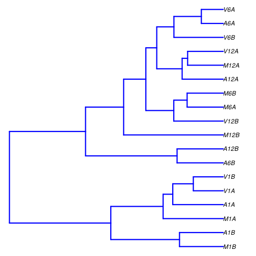

```r
grDevices::pdf("results/sample_tree.pdf")
ape::plot.phylo(ape::as.phylo(hc), type="p", edge.col="blue", edge.width=2, show.node.label=TRUE, no.margin=TRUE)
grDevices::dev.off()
```

Figure 2: Correlation dendrogram of samples

# 6 (6)Analysis of DEGs

The analysis of differentially expressed genes (DEGs) is performed with the glm method of the `edgeR` package (Robinson, McCarthy, and Smyth 2010). The sample comparisons used by this analysis are defined in the header lines of the `targets.txt` file starting with `<CMP>`.

## 6.1 Run `edgeR`

```r
library(edgeR)
countDF <- read.delim("results/countDFeByg.xls", row.names=1, check.names=FALSE)
head(countDF) # best way to see counts!
```

```
##           M1A M1B A1A A1B V1A V1B M6A M6B A6A A6B V6A V6B M12A M12B A12A A12B V12A V12B
## AT1G01010  28 128  99  87 183 118  22  19  77  23 148 201   60   68   66   33  113   60
## AT1G01020  12  47  35  50  49  41   9  11   9   3  42  71   21   37   16    9   20   15
## AT1G01030  19  51  36  33  47  78   5   8   4   4  18  73   16   15    7    5   34   46
## AT1G01040  98 354 259 345 298 350  82  81 128  34 359 530  171  298  183   41  101   88
## AT1G01046   2   2   6   2   6   5   1   1   3   0   4   8    3    4    4    0    0    5
## AT1G01050  33  66  49  78  71 157  59  87  68  18 123 341  180  365   97   24  109   89
```

```r
targets <- utils::read.delim("targets.txt", comment="#")
targets
```

```
##                       FileName SampleName Factor SampleLong Experiment        Date
## 1  ./data/SRR446027_1.fastq.gz        M1A     M1  Mock.1h.A          1 23-Mar-2012
## 2  ./data/SRR446028_1.fastq.gz        M1B     M1  Mock.1h.B          1 23-Mar-2012
## 3  ./data/SRR446029_1.fastq.gz        A1A     A1   Avr.1h.A          1 23-Mar-2012
## 4  ./data/SRR446030_1.fastq.gz        A1B     A1   Avr.1h.B          1 23-Mar-2012
## 5  ./data/SRR446031_1.fastq.gz        V1A     V1   Vir.1h.A          1 23-Mar-2012
## 6  ./data/SRR446032_1.fastq.gz        V1B     V1   Vir.1h.B          1 23-Mar-2012
## 7  ./data/SRR446033_1.fastq.gz        M6A     M6  Mock.6h.A          1 23-Mar-2012
## 8  ./data/SRR446034_1.fastq.gz        M6B     M6  Mock.6h.B          1 23-Mar-2012
## 9  ./data/SRR446035_1.fastq.gz        A6A     A6   Avr.6h.A          1 23-Mar-2012
## 10 ./data/SRR446036_1.fastq.gz        A6B     A6   Avr.6h.B          1 23-Mar-2012
## 11 ./data/SRR446037_1.fastq.gz        V6A     V6   Vir.6h.A          1 23-Mar-2012
## 12 ./data/SRR446038_1.fastq.gz        V6B     V6   Vir.6h.B          1 23-Mar-2012
## 13 ./data/SRR446039_1.fastq.gz       M12A    M12 Mock.12h.A          1 23-Mar-2012
## 14 ./data/SRR446040_1.fastq.gz       M12B    M12 Mock.12h.B          1 23-Mar-2012
## 15 ./data/SRR446041_1.fastq.gz       A12A    A12  Avr.12h.A          1 23-Mar-2012
## 16 ./data/SRR446042_1.fastq.gz       A12B    A12  Avr.12h.B          1 23-Mar-2012
## 17 ./data/SRR446043_1.fastq.gz       V12A    V12  Vir.12h.A          1 23-Mar-2012
## 18 ./data/SRR446044_1.fastq.gz       V12B    V12  Vir.12h.B          1 23-Mar-2012
```

```r
cmp <- systemPipeR::readComp(file="targets.txt", format="matrix", delim="-")
cmp
```

```
## $CMPset1
##       [,1]  [,2]
##  [1,] "M1"  "A1"
##  [2,] "M1"  "V1"
##  [3,] "A1"  "V1"
##  [4,] "M6"  "A6"
##  [5,] "M6"  "V6"
##  [6,] "A6"  "V6"
##  [7,] "M12" "A12"
##  [8,] "M12" "V12"
##  [9,] "A12" "V12"
##
## $CMPset2
##       [,1]  [,2]
##  [1,] "M1"  "A1"
```

[output cut: 35 more lines]

```r
debug(run_edgeR)
edgeDF <- systemPipeR::run_edgeR(countDF=countDF, targets=targets, cmp=cmp[[1]], independent=FALSE, mdsplot="")
```

[output not shown]

[output cut: 232 more lines]

[output not shown]

```r
str(edgeDF)
```

```
## 'data.frame':    145 obs. of  45 variables:
##  $ M1-A1_logFC   : num  -0.0366 -0.1789 0.4071 -0.0829 -0.5014 ...
##  $ M1-A1_logCPM  : num  10.81 9.13 9.18 11.96 6.68 ...
##  $ M1-A1_LR      : num  0.00502 0.15081 0.50277 0.03372 0.17883 ...
##  $ M1-A1_PValue  : num  0.944 0.698 0.478 0.854 0.672 ...
##  $ M1-A1_FDR     : num  1 1 1 1 1 ...
##  $ M1-V1_logFC   : num  -0.711 -0.268 -0.338 -0.154 -0.833 ...
##  $ M1-V1_logCPM  : num  10.81 9.13 9.18 11.96 6.68 ...
##  $ M1-V1_LR      : num  1.918 0.341 0.361 0.116 0.514 ...
##  $ M1-V1_PValue  : num  0.166 0.559 0.548 0.733 0.474 ...
##  $ M1-V1_FDR     : num  0.639 0.852 0.849 0.927 0.844 ...
##  $ A1-V1_logFC   : num  -0.675 -0.089 -0.745 -0.071 -0.332 ...
##  $ A1-V1_logCPM  : num  10.81 9.13 9.18 11.96 6.68 ...
##  $ A1-V1_LR      : num  1.7656 0.041 1.7884 0.0251 0.0996 ...
##  $ A1-V1_PValue  : num  0.184 0.84 0.181 0.874 0.752 ...
```

[output cut: 31 more lines]

```r
edgeDF
```

```
##             M1-A1_logFC M1-A1_logCPM     M1-A1_LR M1-A1_PValue M1-A1_FDR   M1-V1_logFC M1-V1_logCPM
## AT1G01010 -0.0365986934    10.805019 5.021351e-03   0.94350799 1.0000000 -0.7113444412    10.805019
## AT1G01020 -0.1789050689     9.132316 1.508107e-01   0.69776180 1.0000000 -0.2678989538     9.132316
## AT1G01030  0.4071118961     9.178201 5.027701e-01   0.47828549 1.0000000 -0.3378060825     9.178201
## AT1G01040 -0.0828553569    11.963065 3.371732e-02   0.85430940 1.0000000 -0.1538640547    11.963065
## AT1G01046 -0.5013835231     6.677763 1.788274e-01   0.67238292 1.0000000 -0.8333502215     6.677763
## AT1G01050  0.1886458181    11.185637 1.441430e-01   0.70419657 1.0000000 -0.5791618869    11.185637
## AT1G01060  1.4428635335     9.107454 4.601016e+00   0.03195302 0.8502762  3.3408464332     9.107454
## AT1G01070 -2.6080089725     6.628657 2.002846e+00   0.15700417 1.0000000 -3.7279914834     6.628657
## AT1G01073            NA           NA           NA           NA        NA            NA           NA
## AT1G01080  0.0072665974    11.030422 1.974188e-04   0.98878963 1.0000000 -0.3709226830    11.030422
## AT1G01090 -0.2174716028    12.719100 2.121600e-01   0.64507963 1.0000000 -0.3199800100    12.719100
## AT1G01100 -0.0637538301    12.967462 1.415947e-02   0.90528045 1.0000000 -0.3648543279    12.967462
## AT1G01110  0.1334329677     6.779839 1.415914e-02   0.90528156 1.0000000  0.0604936917     6.779839
## AT1G01115            NA           NA           NA           NA        NA            NA           NA
## AT2G01008  0.6642650518     9.722277 1.557157e+00   0.21208198 1.0000000  0.3209583615     9.722277
## AT2G01010  0.6557465292    19.704494 5.718920e-01   0.44950806 1.0000000  0.7676234029    19.704494
## AT2G01020  1.4765739660    14.676683 1.915395e+00   0.16636525 1.0000000  1.3749866850    14.676683
## AT2G01021  0.7463254424    16.724417 6.249714e-01   0.42920586 1.0000000  2.0687125636    16.724417
## AT2G01023  0.6311109574     6.159990 2.375900e-01   0.62595220 1.0000000  2.8680328702     6.159990
## AT3G01010            NA           NA           NA           NA        NA            NA           NA
## AT3G01015 -1.7956305085     5.372937 1.080165e+00   0.29866063 1.0000000  0.0000000000     5.372937
## AT3G01020            NA           NA           NA           NA        NA            NA           NA
##               M1-V1_LR M1-V1_PValue    M1-V1_FDR A1-V1_logFC A1-V1_logCPM     A1-V1_LR A1-V1_PValue
## AT1G01010 1.918384e+00 1.660349e-01 0.6386053484 -0.67474575    10.805019 1.765648e+00 0.1839216202
## AT1G01020 3.406828e-01 5.594353e-01 0.8515497322 -0.08899388     9.132316 4.095834e-02 0.8396183497
## AT1G01030 3.610019e-01 5.479503e-01 0.8493230113 -0.74491798     9.178201 1.788368e+00 0.1811251903
## AT1G01040 1.164017e-01 7.329703e-01 0.9270361211 -0.07100870    11.963065 2.511953e-02 0.8740695895
## AT1G01046 5.136593e-01 4.735591e-01 0.8442353779 -0.33196670     6.677763 9.964030e-02 0.7522617209
## AT1G01050 1.397400e+00 2.371594e-01 0.6752817636 -0.76780770    11.185637 2.552949e+00 0.1100886195
## AT1G01060 1.994605e+01 7.965824e-06 0.0009877622  1.89798290     9.107454 6.568331e+00 0.0103809274
## AT1G01070 4.211073e+00 4.016092e-02 0.4979954215 -1.11998251     6.628657 7.381887e-01 0.3902417157
## AT1G01073           NA           NA           NA          NA           NA           NA           NA
## AT1G01080 5.154414e-01 4.727928e-01 0.8442353779 -0.37818928    11.030422 5.448496e-01 0.4604298125
## AT1G01090 4.593644e-01 4.979212e-01 0.8442353779 -0.10250841    12.719100 4.764518e-02 0.8272127043
## AT1G01100 4.643574e-01 4.955945e-01 0.8442353779 -0.30110050    12.967462 3.205066e-01 0.5713033508
## AT1G01110 2.841748e-03 9.574865e-01 1.0000000000 -0.07293928     6.779839 4.850670e-03 0.9444748261
## AT1G01115           NA           NA           NA          NA           NA           NA           NA
## AT2G01008 3.806465e-01 5.372574e-01 0.8493230113 -0.34330669     9.722277 4.358786e-01 0.5091184299
## AT2G01010 7.812405e-01 3.767620e-01 0.8054911898  0.11187687    19.704494 1.678508e-02 0.8969167363
```

[output cut: 107 more lines]

```
## AT1G01073            NA             NA           NA             NA          NA
## AT1G01080  -0.142147249      11.030422 6.161282e-02    0.803964729  1.00000000
## AT1G01090  -0.456893760      12.719100 8.830640e-01    0.347363836  0.92907665
## AT1G01100  -0.426073795      12.967462 6.349651e-01    0.425539911  0.92907665
## AT1G01110   0.079021497       6.779839 2.951182e-03    0.956676408  1.00000000
## AT1G01115            NA             NA           NA             NA          NA
## AT2G01008  -0.557654745       9.722277 1.181626e+00    0.277025267  0.92907665
## AT2G01010   0.735514368      19.704494 7.179103e-01    0.396830218  0.92907665
## AT2G01020  -1.282140928      14.676683 1.467364e+00    0.225762002  0.92907665
## AT2G01021  -0.191100522      16.724417 4.141340e-02    0.838742031  1.00000000
## AT2G01023  -4.408711274       6.159990 2.731594e+00    0.098381053  0.92907665
## AT3G01010            NA             NA           NA             NA          NA
## AT3G01015   0.000000000       5.372937 0.000000e+00    1.000000000  1.00000000
## AT3G01020            NA             NA           NA             NA          NA
##  [ reached getOption("max.print") -- omitted 123 rows ]
```

Add gene descriptions

```r
# useMart() call fails if mart is down for maintenance
library("biomaRt")
m <- biomaRt::useMart("plants_mart", dataset="athaliana_eg_gene", host="plants.ensembl.org")
m
```

```
## Object of class 'Mart':
##   Using the plants_mart BioMart database
##   Using the athaliana_eg_gene dataset
```

```r
desc <- biomaRt::getBM(attributes=c("tair_locus", "description"), mart=m)
# desc # too big to print
str(desc)
```

```
## 'data.frame':    28730 obs. of  2 variables:
##  $ tair_locus : chr  "AT5G16970" "AT4G32100" "AT2G43120" "AT1G30814" ...
##  $ description: chr  "NADPH-dependent oxidoreductase 2-alkenal reductase [Source:UniProtKB/Swiss-Prot;Acc:Q39172]" "Beta-1,3-N-Acetylglucosaminyltransferase family protein [Source:UniProtKB/TrEMBL;Acc:F4JTI5]" "RmlC-like cupins superfamily protein [Source:TAIR;Acc:AT2G43120]" "unknown protein; Ha…
```

```r
head(desc)
```

```
##   tair_locus
## 1  AT5G16970
## 2  AT4G32100
## 3  AT2G43120
## 4  AT1G30814
## 5  AT3G18710
## 6  AT4G25880
##                                                                                                                                                                                                                                 description
## 1                                                                                                                                               NADPH-dependent oxidoreductase 2-alkenal reductase [Source:UniProtKB/Swiss-Prot;Acc:Q39172]
## 2                                                                                                                                              Beta-1,3-N-Acetylglucosaminyltransferase family protein [Source:UniProtKB/TrEMBL;Acc:F4JTI5]
## 3                                                                                                                                                                          RmlC-like cupins superfamily protein [Source:TAIR;Acc:AT2G43120]
## 4 unknown protein; Has 35333 Blast hits to 34131 proteins in 2444 species: Archae - 798; Bacteria - 22429; Metazoa - 974; Fungi - 991; Plants - 531; Viruses - 0; Other Eukaryotes - 9610 (source: NCBI BLink). [Source:TAIR;Acc:AT1G30814]
## 5                                                                                                                                                               RING-type E3 ubiquitin transferase [Source:UniProtKB/TrEMBL;Acc:A0A178VJJ8]
## 6                                                                                                                                                                                                     pumilio 6 [Source:TAIR;Acc:AT4G25880]
```

```r
# m <- useMart("ensembl", dataset="xmaculatus_gene_ensembl", host="ensembl.org")
# desc <- biomaRt::getBM(attributes=c("band", "description"), mart=m)
desc <- desc[!base::duplicated(desc[,1]),]
descv <- as.character(desc[,2]); names(descv) <- as.character(desc[,1])
save(descv, file="descv.RData") # save for clusterProfiler work
str(descv)
```

```
##  Named chr [1:28279] "NADPH-dependent oxidoreductase 2-alkenal reductase [Source:UniProtKB/Swiss-Prot;Acc:Q39172]" ...
##  - attr(*, "names")= chr [1:28279] "AT5G16970" "AT4G32100" "AT2G43120" "AT1G30814" ...
```

```r
head(descv)
```

```
##                                                                                                                                                                                                                                   AT5G16970
##                                                                                                                                               "NADPH-dependent oxidoreductase 2-alkenal reductase [Source:UniProtKB/Swiss-Prot;Acc:Q39172]"
##                                                                                                                                                                                                                                   AT4G32100
##                                                                                                                                              "Beta-1,3-N-Acetylglucosaminyltransferase family protein [Source:UniProtKB/TrEMBL;Acc:F4JTI5]"
##                                                                                                                                                                                                                                   AT2G43120
##                                                                                                                                                                          "RmlC-like cupins superfamily protein [Source:TAIR;Acc:AT2G43120]"
##                                                                                                                                                                                                                                   AT1G30814
## "unknown protein; Has 35333 Blast hits to 34131 proteins in 2444 species: Archae - 798; Bacteria - 22429; Metazoa - 974; Fungi - 991; Plants - 531; Viruses - 0; Other Eukaryotes - 9610 (source: NCBI BLink). [Source:TAIR;Acc:AT1G30814]"
##                                                                                                                                                                                                                                   AT3G18710
##                                                                                                                                                               "RING-type E3 ubiquitin transferase [Source:UniProtKB/TrEMBL;Acc:A0A178VJJ8]"
##                                                                                                                                                                                                                                   AT4G25880
##                                                                                                                                                                                                     "pumilio 6 [Source:TAIR;Acc:AT4G25880]"
```

```r
names(descv) # this is the list for clusterProfiler
```

[output not shown]

[output cut: 129 more lines]

```r
length(names(descv))
```

```
## [1] 28279
```

```r
edgeDF <- data.frame(edgeDF, Desc=descv[rownames(edgeDF)], check.names=FALSE)
str(edgeDF)
```

```
## 'data.frame':    145 obs. of  46 variables:
##  $ M1-A1_logFC   : num  -0.0366 -0.1789 0.4071 -0.0829 -0.5014 ...
##  $ M1-A1_logCPM  : num  10.81 9.13 9.18 11.96 6.68 ...
##  $ M1-A1_LR      : num  0.00502 0.15081 0.50277 0.03372 0.17883 ...
##  $ M1-A1_PValue  : num  0.944 0.698 0.478 0.854 0.672 ...
##  $ M1-A1_FDR     : num  1 1 1 1 1 ...
##  $ M1-V1_logFC   : num  -0.711 -0.268 -0.338 -0.154 -0.833 ...
##  $ M1-V1_logCPM  : num  10.81 9.13 9.18 11.96 6.68 ...
##  $ M1-V1_LR      : num  1.918 0.341 0.361 0.116 0.514 ...
##  $ M1-V1_PValue  : num  0.166 0.559 0.548 0.733 0.474 ...
##  $ M1-V1_FDR     : num  0.639 0.852 0.849 0.927 0.844 ...
##  $ A1-V1_logFC   : num  -0.675 -0.089 -0.745 -0.071 -0.332 ...
##  $ A1-V1_logCPM  : num  10.81 9.13 9.18 11.96 6.68 ...
##  $ A1-V1_LR      : num  1.7656 0.041 1.7884 0.0251 0.0996 ...
##  $ A1-V1_PValue  : num  0.184 0.84 0.181 0.874 0.752 ...
```

[output cut: 32 more lines]

```r
summary(edgeDF)
```

```
##   M1-A1_logFC        M1-A1_logCPM       M1-A1_LR       M1-A1_PValue       M1-A1_FDR
##  Min.   :-3.08789   Min.   : 5.373   Min.   :0.0000   Min.   :0.03195   Min.   :0.8503
##  1st Qu.:-0.57865   1st Qu.: 6.327   1st Qu.:0.0394   1st Qu.:0.28310   1st Qu.:1.0000
##  Median :-0.01972   Median : 8.054   Median :0.2750   Median :0.60014   Median :1.0000
##  Mean   :-0.01738   Mean   : 8.540   Mean   :0.8177   Mean   :0.55463   Mean   :0.9836
##  3rd Qu.: 0.28278   3rd Qu.:10.174   3rd Qu.:1.1521   3rd Qu.:0.84271   3rd Qu.:1.0000
##  Max.   : 3.37201   Max.   :19.704   Max.   :4.6010   Max.   :1.00000   Max.   :1.0000
##  NA's   :21         NA's   :21       NA's   :21       NA's   :21        NA's   :21
##   M1-V1_logFC       M1-V1_logCPM       M1-V1_LR        M1-V1_PValue        M1-V1_FDR
##  Min.   :-3.7280   Min.   : 5.373   Min.   : 0.0000   Min.   :0.000008   Min.   :0.000988
##  1st Qu.:-0.4269   1st Qu.: 6.327   1st Qu.: 0.1623   1st Qu.:0.168999   1st Qu.:0.638605
##  Median : 0.1056   Median : 8.054   Median : 0.5524   Median :0.457379   Median :0.844235
##  Mean   : 0.3336   Mean   : 8.540   Mean   : 1.4339   Mean   :0.444524   Mean   :0.769926
##  3rd Qu.: 0.9289   3rd Qu.:10.174   3rd Qu.: 1.8919   3rd Qu.:0.687055   3rd Qu.:0.908818
##  Max.   : 6.0176   Max.   :19.704   Max.   :19.9461   Max.   :1.000000   Max.   :1.000000
##  NA's   :21        NA's   :21       NA's   :21        NA's   :21         NA's   :21
##   A1-V1_logFC       A1-V1_logCPM       A1-V1_LR        A1-V1_PValue        A1-V1_FDR
##  Min.   :-2.7407   Min.   : 5.373   Min.   : 0.0000   Min.   :0.000137   Min.   :0.00994
##  1st Qu.:-0.3279   1st Qu.: 6.327   1st Qu.: 0.0895   1st Qu.:0.248268   1st Qu.:0.93627
##  Median : 0.1016   Median : 8.054   Median : 0.4798   Median :0.488505   Median :0.93627
##  Mean   : 0.3510   Mean   : 8.540   Mean   : 1.1532   Mean   :0.510842   Mean   :0.92579
##  3rd Qu.: 0.7794   3rd Qu.:10.174   3rd Qu.: 1.3330   3rd Qu.:0.764906   3rd Qu.:0.99748
##  Max.   : 5.7210   Max.   :19.704   Max.   :14.5384   Max.   :1.000000   Max.   :1.00000
##  NA's   :21        NA's   :21       NA's   :21        NA's   :21         NA's   :21
##   M6-A6_logFC        M6-A6_logCPM       M6-A6_LR        M6-A6_PValue        M6-A6_FDR
##  Min.   :-3.59767   Min.   : 5.373   Min.   :0.00000   Min.   :0.006198   Min.   :0.7686
##  1st Qu.:-0.45701   1st Qu.: 6.327   1st Qu.:0.05942   1st Qu.:0.290969   1st Qu.:0.9998
##  Median : 0.02419   Median : 8.054   Median :0.39272   Median :0.530872   Median :0.9998
##  Mean   : 0.14430   Mean   : 8.540   Mean   :0.83656   Mean   :0.550009   Mean   :0.9979
##  3rd Qu.: 0.59182   3rd Qu.:10.174   3rd Qu.:1.11520   3rd Qu.:0.807442   3rd Qu.:0.9998
##  Max.   : 4.93582   Max.   :19.704   Max.   :7.49176   Max.   :0.999765   Max.   :0.9998
##  NA's   :21         NA's   :21       NA's   :21        NA's   :21         NA's   :21
##   M6-V6_logFC        M6-V6_logCPM       M6-V6_LR         M6-V6_PValue        M6-V6_FDR
##  Min.   :-4.57550   Min.   : 5.373   Min.   : 0.00000   Min.   :0.000528   Min.   :0.0655
##  1st Qu.:-0.68021   1st Qu.: 6.327   1st Qu.: 0.08039   1st Qu.:0.164934   1st Qu.:0.6441
##  Median : 0.00000   Median : 8.054   Median : 0.61473   Median :0.433032   Median :0.8405
##  Mean   :-0.05279   Mean   : 8.540   Mean   : 1.30254   Mean   :0.483930   Mean   :0.8159
##  3rd Qu.: 0.70280   3rd Qu.:10.174   3rd Qu.: 1.92864   3rd Qu.:0.776813   3rd Qu.:1.0000
##  Max.   : 2.99851   Max.   :19.704   Max.   :12.01337   Max.   :1.000000   Max.   :1.0000
##  NA's   :21         NA's   :21       NA's   :21         NA's   :21         NA's   :21
```

[output cut: 25 more lines]

```
##  Min.   :-5.0933   Min.   : 5.373   Min.   : 0.00000   Min.   :0.000303   Min.   :0.03763
##  1st Qu.:-0.2884   1st Qu.: 6.327   1st Qu.: 0.05181   1st Qu.:0.278426   1st Qu.:0.92908
##  Median : 0.1815   Median : 8.054   Median : 0.47591   Median :0.490311   Median :0.97277
##  Mean   : 0.1378   Mean   : 8.540   Mean   : 0.89604   Mean   :0.536752   Mean   :0.95701
##  3rd Qu.: 0.6990   3rd Qu.:10.174   3rd Qu.: 1.17477   3rd Qu.:0.820097   3rd Qu.:1.00000
##  Max.   : 5.2862   Max.   :19.704   Max.   :13.04891   Max.   :1.000000   Max.   :1.00000
##  NA's   :21        NA's   :21       NA's   :21         NA's   :21         NA's   :21
##                                                                                 Desc
##  30S ribosomal protein S14, chloroplastic [Source:UniProtKB/TrEMBL;Acc:A0A1B1W4T5]:  1
##  30S ribosomal protein S16, chloroplastic [Source:UniProtKB/Swiss-Prot;Acc:P56806]:  1
##  30S ribosomal protein S2, chloroplastic [Source:UniProtKB/Swiss-Prot;Acc:P56797] :  1
##  30S ribosomal protein S4, chloroplastic [Source:UniProtKB/TrEMBL;Acc:A0A1B1W4U6] :  1
##  40S ribosomal protein S13-2 [Source:UniProtKB/Swiss-Prot;Acc:P59224]             :  1
##  (Other)                                                                          :136
##  NA's                                                                             :  4
```

```r
head(edgeDF)
```

```
##           M1-A1_logFC M1-A1_logCPM    M1-A1_LR M1-A1_PValue M1-A1_FDR M1-V1_logFC M1-V1_logCPM
## AT1G01010 -0.03659869    10.805019 0.005021351    0.9435080         1  -0.7113444    10.805019
## AT1G01020 -0.17890507     9.132316 0.150810727    0.6977618         1  -0.2678990     9.132316
## AT1G01030  0.40711190     9.178201 0.502770093    0.4782855         1  -0.3378061     9.178201
## AT1G01040 -0.08285536    11.963065 0.033717320    0.8543094         1  -0.1538641    11.963065
## AT1G01046 -0.50138352     6.677763 0.178827372    0.6723829         1  -0.8333502     6.677763
## AT1G01050  0.18864582    11.185637 0.144142986    0.7041966         1  -0.5791619    11.185637
##            M1-V1_LR M1-V1_PValue M1-V1_FDR A1-V1_logFC A1-V1_logCPM   A1-V1_LR A1-V1_PValue
## AT1G01010 1.9183841    0.1660349 0.6386053 -0.67474575    10.805019 1.76564777    0.1839216
## AT1G01020 0.3406828    0.5594353 0.8515497 -0.08899388     9.132316 0.04095834    0.8396183
## AT1G01030 0.3610019    0.5479503 0.8493230 -0.74491798     9.178201 1.78836753    0.1811252
## AT1G01040 0.1164017    0.7329703 0.9270361 -0.07100870    11.963065 0.02511953    0.8740696
## AT1G01046 0.5136593    0.4735591 0.8442354 -0.33196670     6.677763 0.09964030    0.7522617
## AT1G01050 1.3973998    0.2371594 0.6752818 -0.76780770    11.185637 2.55294869    0.1100886
##           A1-V1_FDR M6-A6_logFC M6-A6_logCPM    M6-A6_LR M6-A6_PValue M6-A6_FDR M6-V6_logFC
## AT1G01010 0.9362684 -1.31271888    10.805019 5.422536492   0.01987846 0.9997652  -1.9108676
## AT1G01020 0.9974790  0.61650005     9.132316 0.892825033   0.34471290 0.9997652  -1.3281611
## AT1G01030 0.9362684  0.43407680     9.178201 0.275653648   0.59956422 0.9997652  -1.5391225
## AT1G01040 0.9974790  0.01113629    11.963065 0.000554536   0.98121268 0.9997652  -1.2605551
## AT1G01046 0.9974790 -0.53037723     6.677763 0.127029050   0.72153253 0.9997652  -1.3391740
## AT1G01050 0.9362684  0.70414518    11.185637 1.991678564   0.15816548 0.9997652  -0.4357212
##           M6-V6_logCPM   M6-V6_LR M6-V6_PValue  M6-V6_FDR A6-V6_logFC A6-V6_logCPM   A6-V6_LR
## AT1G01010    10.805019 12.0133682 0.0005282031 0.06549719  -0.5981487    10.805019  1.3205496
## AT1G01020     9.132316  6.7797040 0.0092200176 0.37395564  -1.9446612     9.132316 11.8305568
## AT1G01030     9.178201  5.4841842 0.0191892725 0.39657830  -1.9731993     9.178201  7.4363079
## AT1G01040    11.963065  7.4037050 0.0065089681 0.37395564  -1.2716914    11.963065  7.4387488
## AT1G01046     6.677763  1.0627861 0.3025805992 0.83326993  -0.8087968     6.677763  0.4251803
## AT1G01050    11.185637  0.8486326 0.3569394692 0.83326993  -1.1398664    11.185637  5.3875815
##           A6-V6_PValue  A6-V6_FDR M12-A12_logFC M12-A12_logCPM M12-A12_LR M12-A12_PValue
## AT1G01010 0.2504934366 0.55376426    -0.9425382      10.805019 3.14907700     0.07596992
## AT1G01020 0.0005826657 0.07225054    -0.1530596       9.132316 0.08599322     0.76933412
## AT1G01030 0.0063920893 0.19815477     0.0407148       9.178201 0.00328284     0.95430935
## AT1G01040 0.0063834255 0.19815477    -0.1168959      11.963065 0.06526875     0.79835433
## AT1G01046 0.5143634037 0.75036544    -0.3222914       6.677763 0.07051225     0.79059240
## AT1G01050 0.0202805602 0.28386193     0.9329752      11.185637 3.78122392     0.05183073
##           M12-A12_FDR M12-V12_logFC M12-V12_logCPM M12-V12_LR M12-V12_PValue M12-V12_FDR
## AT1G01010   0.4454602    -1.3808164      10.805019  6.9614272   8.328557e-03 0.206548217
## AT1G01020   0.9416351    -0.3143787       9.132316  0.4076143   5.231829e-01 0.888694225
## AT1G01030   1.0000000    -2.4024591       9.178201 15.6717157   7.534249e-05 0.009342469
## AT1G01040   0.9518840     0.2406833      11.963065  0.2758746   5.994180e-01 0.900386289
## AT1G01046   0.9517811    -0.6587695       6.677763  0.3091269   5.782164e-01 0.900386289
## AT1G01050   0.4284674     0.3747836      11.185637  0.6412900   4.232441e-01 0.786275862
##           A12-V12_logFC A12-V12_logCPM  A12-V12_LR A12-V12_PValue A12-V12_FDR
## AT1G01010    -0.4382782      10.805019  0.69786734    0.403501229  0.92907665
## AT1G01020    -0.1613191       9.132316  0.08849653    0.766097279  1.00000000
## AT1G01030    -2.4431739       9.178201 13.04890979    0.000303461  0.03762916
## AT1G01040     0.3575792      11.963065  0.59092756    0.442060662  0.92907665
## AT1G01046    -0.3364781       6.677763  0.06755896    0.794924666  1.00000000
## AT1G01050    -0.5581917      11.185637  1.32442276    0.249799843  0.92907665
##                                                                                   Desc
## AT1G01010     NAC domain-containing protein 1 [Source:UniProtKB/Swiss-Prot;Acc:Q0WV96]
## AT1G01020                                    ARV1 [Source:UniProtKB/TrEMBL;Acc:Q5MK24]
## AT1G01030                                NGA3 [Source:UniProtKB/TrEMBL;Acc:A0A178W3T3]
## AT1G01040                            Dicer-like 1 [Source:UniProtKB/TrEMBL;Acc:F4HQG6]
## AT1G01046                                   MIR838a; miRNA [Source:TAIR;Acc:AT1G01046]
## AT1G01050 Soluble inorganic pyrophosphatase 1 [Source:UniProtKB/Swiss-Prot;Acc:Q93V56]
```

```r
write.table(edgeDF, "./results/edgeRglm_allcomp.xls", quote=FALSE, sep="\t", col.names = NA)
```

## 6.2 Plot DEG results

Filter and plot DEG results for up and down regulated genes. The definition of *up* and *down* is given in the corresponding help file. To open it, type `?filterDEGs` in the R console.

```r
edgeDF <- read.delim("results/edgeRglm_allcomp.xls", row.names=1, check.names=FALSE)
str(edgeDF)
```

```
## 'data.frame':    145 obs. of  46 variables:
##  $ M1-A1_logFC   : num  -0.0366 -0.1789 0.4071 -0.0829 -0.5014 ...
##  $ M1-A1_logCPM  : num  10.81 9.13 9.18 11.96 6.68 ...
##  $ M1-A1_LR      : num  0.00502 0.15081 0.50277 0.03372 0.17883 ...
##  $ M1-A1_PValue  : num  0.944 0.698 0.478 0.854 0.672 ...
##  $ M1-A1_FDR     : num  1 1 1 1 1 ...
##  $ M1-V1_logFC   : num  -0.711 -0.268 -0.338 -0.154 -0.833 ...
##  $ M1-V1_logCPM  : num  10.81 9.13 9.18 11.96 6.68 ...
##  $ M1-V1_LR      : num  1.918 0.341 0.361 0.116 0.514 ...
##  $ M1-V1_PValue  : num  0.166 0.559 0.548 0.733 0.474 ...
##  $ M1-V1_FDR     : num  0.639 0.852 0.849 0.927 0.844 ...
##  $ A1-V1_logFC   : num  -0.675 -0.089 -0.745 -0.071 -0.332 ...
##  $ A1-V1_logCPM  : num  10.81 9.13 9.18 11.96 6.68 ...
##  $ A1-V1_LR      : num  1.7656 0.041 1.7884 0.0251 0.0996 ...
##  $ A1-V1_PValue  : num  0.184 0.84 0.181 0.874 0.752 ...
```

[output cut: 32 more lines]

```r
summary(edgeDF)
```

```
##   M1-A1_logFC        M1-A1_logCPM       M1-A1_LR       M1-A1_PValue       M1-A1_FDR
##  Min.   :-3.08789   Min.   : 5.373   Min.   :0.0000   Min.   :0.03195   Min.   :0.8503
##  1st Qu.:-0.57865   1st Qu.: 6.327   1st Qu.:0.0394   1st Qu.:0.28310   1st Qu.:1.0000
##  Median :-0.01972   Median : 8.054   Median :0.2750   Median :0.60014   Median :1.0000
##  Mean   :-0.01738   Mean   : 8.540   Mean   :0.8177   Mean   :0.55463   Mean   :0.9836
##  3rd Qu.: 0.28278   3rd Qu.:10.174   3rd Qu.:1.1521   3rd Qu.:0.84271   3rd Qu.:1.0000
##  Max.   : 3.37201   Max.   :19.704   Max.   :4.6010   Max.   :1.00000   Max.   :1.0000
##  NA's   :21         NA's   :21       NA's   :21       NA's   :21        NA's   :21
##   M1-V1_logFC       M1-V1_logCPM       M1-V1_LR        M1-V1_PValue        M1-V1_FDR
##  Min.   :-3.7280   Min.   : 5.373   Min.   : 0.0000   Min.   :0.000008   Min.   :0.000988
##  1st Qu.:-0.4269   1st Qu.: 6.327   1st Qu.: 0.1623   1st Qu.:0.168999   1st Qu.:0.638605
##  Median : 0.1056   Median : 8.054   Median : 0.5524   Median :0.457379   Median :0.844235
##  Mean   : 0.3336   Mean   : 8.540   Mean   : 1.4339   Mean   :0.444524   Mean   :0.769926
##  3rd Qu.: 0.9289   3rd Qu.:10.174   3rd Qu.: 1.8919   3rd Qu.:0.687055   3rd Qu.:0.908818
##  Max.   : 6.0176   Max.   :19.704   Max.   :19.9461   Max.   :1.000000   Max.   :1.000000
##  NA's   :21        NA's   :21       NA's   :21        NA's   :21         NA's   :21
##   A1-V1_logFC       A1-V1_logCPM       A1-V1_LR        A1-V1_PValue        A1-V1_FDR
##  Min.   :-2.7407   Min.   : 5.373   Min.   : 0.0000   Min.   :0.000137   Min.   :0.00994
##  1st Qu.:-0.3279   1st Qu.: 6.327   1st Qu.: 0.0895   1st Qu.:0.248268   1st Qu.:0.93627
##  Median : 0.1016   Median : 8.054   Median : 0.4798   Median :0.488505   Median :0.93627
##  Mean   : 0.3510   Mean   : 8.540   Mean   : 1.1532   Mean   :0.510842   Mean   :0.92579
##  3rd Qu.: 0.7794   3rd Qu.:10.174   3rd Qu.: 1.3330   3rd Qu.:0.764906   3rd Qu.:0.99748
##  Max.   : 5.7210   Max.   :19.704   Max.   :14.5384   Max.   :1.000000   Max.   :1.00000
##  NA's   :21        NA's   :21       NA's   :21        NA's   :21         NA's   :21
##   M6-A6_logFC        M6-A6_logCPM       M6-A6_LR        M6-A6_PValue        M6-A6_FDR
##  Min.   :-3.59767   Min.   : 5.373   Min.   :0.00000   Min.   :0.006198   Min.   :0.7686
##  1st Qu.:-0.45701   1st Qu.: 6.327   1st Qu.:0.05942   1st Qu.:0.290969   1st Qu.:0.9998
##  Median : 0.02419   Median : 8.054   Median :0.39272   Median :0.530872   Median :0.9998
##  Mean   : 0.14430   Mean   : 8.540   Mean   :0.83656   Mean   :0.550009   Mean   :0.9979
##  3rd Qu.: 0.59182   3rd Qu.:10.174   3rd Qu.:1.11520   3rd Qu.:0.807442   3rd Qu.:0.9998
##  Max.   : 4.93582   Max.   :19.704   Max.   :7.49176   Max.   :0.999765   Max.   :0.9998
##  NA's   :21         NA's   :21       NA's   :21        NA's   :21         NA's   :21
##   M6-V6_logFC        M6-V6_logCPM       M6-V6_LR         M6-V6_PValue        M6-V6_FDR
##  Min.   :-4.57550   Min.   : 5.373   Min.   : 0.00000   Min.   :0.000528   Min.   :0.0655
##  1st Qu.:-0.68021   1st Qu.: 6.327   1st Qu.: 0.08039   1st Qu.:0.164934   1st Qu.:0.6441
##  Median : 0.00000   Median : 8.054   Median : 0.61473   Median :0.433032   Median :0.8405
##  Mean   :-0.05279   Mean   : 8.540   Mean   : 1.30254   Mean   :0.483930   Mean   :0.8159
##  3rd Qu.: 0.70280   3rd Qu.:10.174   3rd Qu.: 1.92864   3rd Qu.:0.776813   3rd Qu.:1.0000
##  Max.   : 2.99851   Max.   :19.704   Max.   :12.01337   Max.   :1.000000   Max.   :1.0000
##  NA's   :21         NA's   :21       NA's   :21         NA's   :21         NA's   :21
```

[output cut: 25 more lines]

```
##  Min.   :-5.0933   Min.   : 5.373   Min.   : 0.00000   Min.   :0.000303   Min.   :0.03763
##  1st Qu.:-0.2884   1st Qu.: 6.327   1st Qu.: 0.05181   1st Qu.:0.278426   1st Qu.:0.92908
##  Median : 0.1815   Median : 8.054   Median : 0.47591   Median :0.490311   Median :0.97277
##  Mean   : 0.1378   Mean   : 8.540   Mean   : 0.89604   Mean   :0.536752   Mean   :0.95701
##  3rd Qu.: 0.6990   3rd Qu.:10.174   3rd Qu.: 1.17477   3rd Qu.:0.820097   3rd Qu.:1.00000
##  Max.   : 5.2862   Max.   :19.704   Max.   :13.04891   Max.   :1.000000   Max.   :1.00000
##  NA's   :21        NA's   :21       NA's   :21         NA's   :21         NA's   :21
##                                                                                 Desc
##  30S ribosomal protein S14, chloroplastic [Source:UniProtKB/TrEMBL;Acc:A0A1B1W4T5]:  1
##  30S ribosomal protein S16, chloroplastic [Source:UniProtKB/Swiss-Prot;Acc:P56806]:  1
##  30S ribosomal protein S2, chloroplastic [Source:UniProtKB/Swiss-Prot;Acc:P56797] :  1
##  30S ribosomal protein S4, chloroplastic [Source:UniProtKB/TrEMBL;Acc:A0A1B1W4U6] :  1
##  40S ribosomal protein S13-2 [Source:UniProtKB/Swiss-Prot;Acc:P59224]             :  1
##  (Other)                                                                          :136
##  NA's                                                                             :  4
```

```r
head(edgeDF)
```

```
##           M1-A1_logFC M1-A1_logCPM    M1-A1_LR M1-A1_PValue M1-A1_FDR M1-V1_logFC M1-V1_logCPM
## AT1G01010 -0.03659869    10.805019 0.005021351    0.9435080         1  -0.7113444    10.805019
## AT1G01020 -0.17890507     9.132316 0.150810727    0.6977618         1  -0.2678990     9.132316
## AT1G01030  0.40711190     9.178201 0.502770093    0.4782855         1  -0.3378061     9.178201
## AT1G01040 -0.08285536    11.963065 0.033717320    0.8543094         1  -0.1538641    11.963065
## AT1G01046 -0.50138352     6.677763 0.178827372    0.6723829         1  -0.8333502     6.677763
## AT1G01050  0.18864582    11.185637 0.144142986    0.7041966         1  -0.5791619    11.185637
##            M1-V1_LR M1-V1_PValue M1-V1_FDR A1-V1_logFC A1-V1_logCPM   A1-V1_LR A1-V1_PValue
## AT1G01010 1.9183841    0.1660349 0.6386053 -0.67474575    10.805019 1.76564777    0.1839216
## AT1G01020 0.3406828    0.5594353 0.8515497 -0.08899388     9.132316 0.04095834    0.8396183
## AT1G01030 0.3610019    0.5479503 0.8493230 -0.74491798     9.178201 1.78836753    0.1811252
## AT1G01040 0.1164017    0.7329703 0.9270361 -0.07100870    11.963065 0.02511953    0.8740696
## AT1G01046 0.5136593    0.4735591 0.8442354 -0.33196670     6.677763 0.09964030    0.7522617
## AT1G01050 1.3973998    0.2371594 0.6752818 -0.76780770    11.185637 2.55294869    0.1100886
##           A1-V1_FDR M6-A6_logFC M6-A6_logCPM    M6-A6_LR M6-A6_PValue M6-A6_FDR M6-V6_logFC
## AT1G01010 0.9362684 -1.31271888    10.805019 5.422536492   0.01987846 0.9997652  -1.9108676
## AT1G01020 0.9974790  0.61650005     9.132316 0.892825033   0.34471290 0.9997652  -1.3281611
## AT1G01030 0.9362684  0.43407680     9.178201 0.275653648   0.59956422 0.9997652  -1.5391225
## AT1G01040 0.9974790  0.01113629    11.963065 0.000554536   0.98121268 0.9997652  -1.2605551
## AT1G01046 0.9974790 -0.53037723     6.677763 0.127029050   0.72153253 0.9997652  -1.3391740
## AT1G01050 0.9362684  0.70414518    11.185637 1.991678564   0.15816548 0.9997652  -0.4357212
##           M6-V6_logCPM   M6-V6_LR M6-V6_PValue  M6-V6_FDR A6-V6_logFC A6-V6_logCPM   A6-V6_LR
## AT1G01010    10.805019 12.0133682 0.0005282031 0.06549719  -0.5981487    10.805019  1.3205496
## AT1G01020     9.132316  6.7797040 0.0092200176 0.37395564  -1.9446612     9.132316 11.8305568
## AT1G01030     9.178201  5.4841842 0.0191892725 0.39657830  -1.9731993     9.178201  7.4363079
## AT1G01040    11.963065  7.4037050 0.0065089681 0.37395564  -1.2716914    11.963065  7.4387488
## AT1G01046     6.677763  1.0627861 0.3025805992 0.83326993  -0.8087968     6.677763  0.4251803
## AT1G01050    11.185637  0.8486326 0.3569394692 0.83326993  -1.1398664    11.185637  5.3875815
##           A6-V6_PValue  A6-V6_FDR M12-A12_logFC M12-A12_logCPM M12-A12_LR M12-A12_PValue
## AT1G01010 0.2504934366 0.55376426    -0.9425382      10.805019 3.14907700     0.07596992
## AT1G01020 0.0005826657 0.07225054    -0.1530596       9.132316 0.08599322     0.76933412
## AT1G01030 0.0063920893 0.19815477     0.0407148       9.178201 0.00328284     0.95430935
## AT1G01040 0.0063834255 0.19815477    -0.1168959      11.963065 0.06526875     0.79835433
## AT1G01046 0.5143634037 0.75036544    -0.3222914       6.677763 0.07051225     0.79059240
## AT1G01050 0.0202805602 0.28386193     0.9329752      11.185637 3.78122392     0.05183073
##           M12-A12_FDR M12-V12_logFC M12-V12_logCPM M12-V12_LR M12-V12_PValue M12-V12_FDR
## AT1G01010   0.4454602    -1.3808164      10.805019  6.9614272   8.328557e-03 0.206548217
## AT1G01020   0.9416351    -0.3143787       9.132316  0.4076143   5.231829e-01 0.888694225
## AT1G01030   1.0000000    -2.4024591       9.178201 15.6717157   7.534249e-05 0.009342469
## AT1G01040   0.9518840     0.2406833      11.963065  0.2758746   5.994180e-01 0.900386289
## AT1G01046   0.9517811    -0.6587695       6.677763  0.3091269   5.782164e-01 0.900386289
## AT1G01050   0.4284674     0.3747836      11.185637  0.6412900   4.232441e-01 0.786275862
##           A12-V12_logFC A12-V12_logCPM  A12-V12_LR A12-V12_PValue A12-V12_FDR
## AT1G01010    -0.4382782      10.805019  0.69786734    0.403501229  0.92907665
## AT1G01020    -0.1613191       9.132316  0.08849653    0.766097279  1.00000000
## AT1G01030    -2.4431739       9.178201 13.04890979    0.000303461  0.03762916
## AT1G01040     0.3575792      11.963065  0.59092756    0.442060662  0.92907665
## AT1G01046    -0.3364781       6.677763  0.06755896    0.794924666  1.00000000
## AT1G01050    -0.5581917      11.185637  1.32442276    0.249799843  0.92907665
##                                                                                   Desc
## AT1G01010     NAC domain-containing protein 1 [Source:UniProtKB/Swiss-Prot;Acc:Q0WV96]
## AT1G01020                                    ARV1 [Source:UniProtKB/TrEMBL;Acc:Q5MK24]
## AT1G01030                                NGA3 [Source:UniProtKB/TrEMBL;Acc:A0A178W3T3]
## AT1G01040                            Dicer-like 1 [Source:UniProtKB/TrEMBL;Acc:F4HQG6]
## AT1G01046                                   MIR838a; miRNA [Source:TAIR;Acc:AT1G01046]
## AT1G01050 Soluble inorganic pyrophosphatase 1 [Source:UniProtKB/Swiss-Prot;Acc:Q93V56]
```

```r
pdf("results/DEGcounts.pdf")
DEG_list <- systemPipeR::filterDEGs(degDF=edgeDF, filter=c(Fold=2, FDR=20))
# finally a DEG list
str(DEG_list)
```

```
## List of 4
##  $ UporDown:List of 9
##   ..$ M1-A1  : NULL
##   ..$ M1-V1  : chr [1:2] "AT1G01060" "ATCG00240"
##   ..$ A1-V1  : chr [1:3] "AT3G01140" "AT3G01142" "ATCG00240"
##   ..$ M6-A6  : NULL
##   ..$ M6-V6  : chr "AT1G01010"
##   ..$ A6-V6  : chr [1:4] "AT1G01020" "AT1G01030" "AT1G01040" "ATCG00490"
##   ..$ M12-A12: chr [1:7] "AT1G01080" "AT1G01090" "AT5G01110" "ATCG00280" ...
##   ..$ M12-V12: chr [1:4] "AT1G01030" "AT1G01080" "AT4G00040" "AT5G01100"
##   ..$ A12-V12: chr "AT1G01030"
##  $ Up      :List of 9
##   ..$ M1-A1  : NULL
##   ..$ M1-V1  : chr [1:2] "AT1G01060" "ATCG00240"
##   ..$ A1-V1  : chr [1:3] "AT3G01140" "AT3G01142" "ATCG00240"
##   ..$ M6-A6  : NULL
##   ..$ M6-V6  : NULL
##   ..$ A6-V6  : chr "ATCG00490"
##   ..$ M12-A12: chr [1:3] "AT1G01080" "AT1G01090" "AT5G01110"
##   ..$ M12-V12: chr [1:2] "AT1G01080" "AT4G00040"
##   ..$ A12-V12: NULL
##  $ Down    :List of 9
##   ..$ M1-A1  : NULL
##   ..$ M1-V1  : NULL
##   ..$ A1-V1  : NULL
##   ..$ M6-A6  : NULL
##   ..$ M6-V6  : chr "AT1G01010"
##   ..$ A6-V6  : chr [1:3] "AT1G01020" "AT1G01030" "AT1G01040"
##   ..$ M12-A12: chr [1:4] "ATCG00280" "ATCG00330" "ATCG00490" "ATMG00020"
##   ..$ M12-V12: chr [1:2] "AT1G01030" "AT5G01100"
##   ..$ A12-V12: chr "AT1G01030"
##  $ Summary :'data.frame':    9 obs. of  4 variables:
##   ..$ Comparisons      : Factor w/ 9 levels "A1-V1","A12-V12",..: 4 5 1 8 9 3 6 7 2
##   ..$ Counts_Up_or_Down: int [1:9] 0 2 3 0 1 4 7 4 1
##   ..$ Counts_Up        : int [1:9] 0 2 3 0 0 1 3 2 0
##   ..$ Counts_Down      : int [1:9] 0 0 0 0 1 3 4 2 1
```

```r
DEG_list
```

```
## $UporDown
## $UporDown$`M1-A1`
## NULL
##
## $UporDown$`M1-V1`
## [1] "AT1G01060" "ATCG00240"
##
## $UporDown$`A1-V1`
## [1] "AT3G01140" "AT3G01142" "ATCG00240"
##
## $UporDown$`M6-A6`
## NULL
##
## $UporDown$`M6-V6`
## [1] "AT1G01010"
##
## $UporDown$`A6-V6`
## [1] "AT1G01020" "AT1G01030" "AT1G01040" "ATCG00490"
##
## $UporDown$`M12-A12`
## [1] "AT1G01080" "AT1G01090" "AT5G01110" "ATCG00280" "ATCG00330" "ATCG00490" "ATMG00020"
##
## $UporDown$`M12-V12`
## [1] "AT1G01030" "AT1G01080" "AT4G00040" "AT5G01100"
##
## $UporDown$`A12-V12`
## [1] "AT1G01030"
##
##
## $Up
## $Up$`M1-A1`
## NULL
##
## $Up$`M1-V1`
## [1] "AT1G01060" "ATCG00240"
##
## $Up$`A1-V1`
## [1] "AT3G01140" "AT3G01142" "ATCG00240"
##
## $Up$`M6-A6`
```

[output cut: 43 more lines]

```
## $Down$`A12-V12`
## [1] "AT1G01030"
##
##
## $Summary
##         Comparisons Counts_Up_or_Down Counts_Up Counts_Down
## M1-A1         M1-A1                 0         0           0
## M1-V1         M1-V1                 2         2           0
## A1-V1         A1-V1                 3         3           0
## M6-A6         M6-A6                 0         0           0
## M6-V6         M6-V6                 1         0           1
## A6-V6         A6-V6                 4         1           3
## M12-A12     M12-A12                 7         3           4
## M12-V12     M12-V12                 4         2           2
## A12-V12     A12-V12                 1         0           1
```

```r
DEG_list$Summary
```

```
##         Comparisons Counts_Up_or_Down Counts_Up Counts_Down
## M1-A1         M1-A1                 0         0           0
## M1-V1         M1-V1                 2         2           0
## A1-V1         A1-V1                 3         3           0
## M6-A6         M6-A6                 0         0           0
## M6-V6         M6-V6                 1         0           1
## A6-V6         A6-V6                 4         1           3
## M12-A12     M12-A12                 7         3           4
## M12-V12     M12-V12                 4         2           2
## A12-V12     A12-V12                 1         0           1
```

```r
dev.off()
```

```r
write.table(DEG_list$Summary, "./results/DEGcounts.xls", quote=FALSE, sep="\t", row.names=FALSE)
```

[figure not shown]

## 6.3 Venn diagrams of DEG sets

The `overLapper` function can compute Venn intersects for large numbers of sample sets (up to 20 or more) and plots 2-5 way Venn diagrams. A useful feature is the possiblity to combine the counts from several Venn comparisons with the same number of sample sets in a single Venn diagram (here for 4 up and down DEG sets).

```r
vennsetup <- overLapper(DEG_list$Up[6:9], type="vennsets")
vennsetup
```

```
## An instance of 'VENNset' with 4 label sets
```

```r
vennsetdown <- overLapper(DEG_list$Down[6:9], type="vennsets")
vennsetdown
```

```
## An instance of 'VENNset' with 4 label sets
```

[figure not shown]

```r
pdf("results/vennplot.pdf")
vennPlot(list(vennsetup, vennsetdown), mymain="", mysub="", colmode=2, ccol=c("blue", "red"))
dev.off()
```

Figure 4: Venn Diagram for 4 Up and Down DEG Sets

# 7 (7)GO term enrichment analysis

```r
library(GO.db)
library(AnnotationDbi)
source("../../systemPipeR/R/AllClasses.R")
```

```
## Creating a new generic function for 'results' in the global environment
```

```r
source("../../systemPipeR/R/fastqQuality.R")
source("../../systemPipeR/R/overLapper.R")
source("../../systemPipeR/R/utilities.R")
source("../../systemPipeR/R/geneSetAnalysis.R")
.readGOorg <- function(myfile, colno, org) {
    # browser()
    go_org <- read.delim(myfile, na.strings = "", header=FALSE, comment.char = "!", sep="\t")
        go_org <- go_org[ , colno]
        names(go_org) <- c("GOID", "GeneID", "GOCAT")
    if(org == "Arabidopsis") {
        go_org[,"GeneID"] <- gsub(".*(AT.G\\d\\d\\d\\d\\d).*", "\\1", as.character(go_org[,2]), perl=TRUE)
            go_org <- go_org[grep("^AT.G\\d\\d\\d\\d\\d", as.character(go_org$GeneID), perl=TRUE),]
            go_org <- go_org[!duplicated(paste(go_org[,"GOID"], gsub("\\.\\d{1,}", "", as.character(go_org[,"GeneID"]), perl=TRUE), sep="_")),]
        }
        go_org <- na.omit(go_org)
    ## Make GO cat labels consistent, e.g. from BioMart
    gocat <- as.character(go_org$GOCAT)
    gocat[gocat=="molecular_function"] <- "F"
    gocat[gocat=="biological_process"] <- "P"
    gocat[gocat=="cellular_component"] <- "C"
    go_org[,"GOCAT"] <- gocat
    ## Split data frame by category
        GO_MF_DF <- go_org[go_org[,3]=="F",]
        GO_BP_DF <- go_org[go_org[,3]=="P",]
        GO_CC_DF <- go_org[go_org[,3]=="C",]

    ## Generates data frame (go_df) containing the commonly used components for all GO nodes: GOID, GO Term and Ontology Type. This step is only required if "go_df" hasn't been imported with the above load() function.
    go_df <- data.frame(GOID=names(Term(GOTERM)), Term=Term(GOTERM), Ont=Ontology(GOTERM))
        go_df <- na.omit(go_df)

    ## Return results
    dflist <- list(D_BP=GO_BP_DF, D_CC=GO_CC_DF, D_MF=GO_MF_DF, GO_DF=go_df)
    return(dflist)
}
.gene2GOlist <- function(catdf, rootUK=FALSE) { # If the argument 'rootUK' is set to TRUE then the root nodes are treated as terminal nodes to account for the new unknown terms
    # browser()
        ## Import required data frames
    GO_MF_DF <- catdf$D_MF
        GO_BP_DF <- catdf$D_BP
        GO_CC_DF <- catdf$D_CC

    ## Populate each GO node with associated gene ids
    for(i in c("MF","BP","CC")) {
                if(i=="MF") {
                        go_offspr_list <- as.list(GOMFOFFSPRING) }
                if(i=="BP") {
                        go_offspr_list <- as.list(GOBPOFFSPRING) }
                if(i=="CC") {
                        go_offspr_list <- as.list(GOCCOFFSPRING) }
                go_offspr_list <- lapply(go_offspr_list, unlist); go_offspr_list <- lapply(go_offspr_list, as.vector) # clean-up step for the list
                go_offspr_list_temp <- lapply(names(go_offspr_list), function(x) c(x, go_offspr_list[[x]]) ) # include list component (GOID) names in corresponding (GOID) vectors
                names(go_offspr_list_temp) <- names(go_offspr_list) # names list components after go_offspr_list
                go_offspr_list <- go_offspr_list_temp
                go_offspr_list <- lapply(go_offspr_list, function(x) x[!is.na(x)]) # remove NAs in vectors

        ## Treat root nodes as terminal nodes to account for the new unknown terms. This step removes the offspring information from the root nodes.
        if(rootUK==TRUE) {
            if(i=="MF") { go_offspr_list[["GO:0003674"]] <- c("GO:0003674") }
            if(i=="BP") { go_offspr_list[["GO:0008150"]] <- c("GO:0008150") }
            if(i=="CC") { go_offspr_list[["GO:0005575"]] <- c("GO:0005575") }
        }

        ## Retrieve gene (affy) IDs for GOID vectors
        if(i=="MF") {
                        MF_node_gene_list <- lapply(go_offspr_list, function(x) unique(as.vector(GO_MF_DF[GO_MF_DF$GOID %in% x, 2])))
                }
        if(i=="BP") {
                        BP_node_gene_list <- lapply(go_offspr_list, function(x) unique(as.vector(GO_BP_DF[GO_BP_DF$GOID %in% x, 2])))
                }
        if(i=="CC") {
                        CC_node_gene_list <- lapply(go_offspr_list, function(x) unique(as.vector(GO_CC_DF[GO_CC_DF$GOID %in% x, 2])))
                }
        cat("\n", paste("'", i, "_node_gene_list'", sep=""), "with gene-to-GO-OFFSPRING associations created.", "\n")
        }
    node_gene_list <-list(L_BP=BP_node_gene_list, L_CC=CC_node_gene_list, L_MF=MF_node_gene_list)
    return(node_gene_list)
}
makeCATdb <- function(myfile, lib=NULL, org="", colno = c(1,2,3), idconv=NULL, rootUK=FALSE) {
    if(!is.null(lib) & !is.null(myfile)) stop("Arguments myfile and lib are exclusive. One of them needs to be assigned NULL.")
    if(!is.null(lib)) {
        catdf <- .sampleDFgene2GO(lib=lib)
    }
    if(!is.null(myfile)) {
        catdf <- .readGOorg(myfile=myfile, org=org, colno=colno)
    }
    catlist <- .gene2GOlist(catdf=catdf, rootUK=rootUK)
    catdblist <- c(catmap=list(catdf), catlist=list(catlist), idconv=list(idconv))
    catdb <- as(catdblist, "catDB")
    cat("\n", "makeCATdb successful.", "\n")
    return(catdb)
}
cat("Done\n")
```

```
## Done
```